# 통계밥법론2 Chap3 실습코드

202140191 엄태훈

2021-09-18(SAT)

# Chap4 Two-Way Contigency Tables

우리는 앞선 챕터까지 대부분 일차원의 빈도표를 이용하여 분석을 진행하였다.  
하지만, 실생활에서 일차원 빈도표처럼 간단한 빈도표를 보는 경우보다 이원 혹은 그 이상의 다차원 분할표를 보는 경우가 많다.  
다차원은 일차원에 비해 변수가 많으므로, 분석을 진행함에 있어 더 까다롭기 때문에 조금은 다른 분석방법과 데이터 처리 과정을 연습하는 것이 필요하다.

**이원 빈도표 분석(two-way frequency tables)**은 두 변수 간의 연관성에 대해 알아보는 분석이다.  
다양한 시각화 기법들은 연관성의 패턴을 시각화 하는데 도움이 되며, 몇몇 지역을 셀의 빈도를 나타내기 위해 사용하기도 한다.

이러한 방법들 중 오즈비 또는 일반적인 연관 패턴에 더 집중하여 알아보도록 한다.

## 4.1 Introduction

대부분의 통계 분석 방법은 변수 간의 관계를 이해하는 것과 관련이 있으며, 범주형 변수는 이러한 관계를 종종 분할표에 의해 연구되기도 한다.

**Thomas Carlyle**은 숫자표로 전달된 메시지를 이해하는 것은 어렵다고 말했다.  
수많은 정보가 내포된 숫자표를 바로 이해하는 것보다는 데이터의 일부분만을 먼저 살펴본다던지, **EDA**를 활용하는 등 전반적인 데이터의 구조를 보는 것이 좋다.  
Chapter4에서는 두 범주형 변수 간의 연관성을 이해하기 위한 그래픽 방법들에 대해 알아본다.

- 몇몇의 예시에서는 세 번째 변수를 이용하여 두 주요 변수 간의 관계를 파악하기도 한다.
- 두 변수 사이에 연관성이 존재하는지 시험하기 위한 몇몇의 수치 및 통계적 방법과 연관성의 강도의 측정에 대해서 알아본다.
- 변수 간의 연관 패턴을 설명하는 데 도움이 되는 그래픽 방법이 가장 중요하다.
- **fourfold**, **association plot**, **agreement plot**, **trilinear plot**에 대해서 알아본다.

*Example 4.2: Hair color and eye color*

```r
(hec <- margin.table(HairEyeColor,2:1))
```

```
##        Hair
## Eye     Black Brown Red Blond
##   Brown    68   119  26     7
##   Blue     20    84  17    94
##   Hazel    15    54  14    10
##   Green     5    29  14    16
```

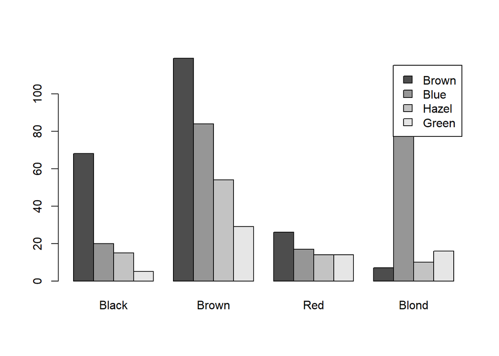

```r
barplot(hec, beside = TRUE, legend = TRUE)
```

`HairEyeColr`데이터를 `barplot`을 통해 머리색과 눈색 사이의 관계를 시각화 하였다.  
빈도표를 통해 데이터를 탐색하는 것보다는 `barplot`을 통해 시각화하여 살펴본 결과가 더 한 눈에 들어오는 것을 알 수 있다.  
전체적으로 머리색, 눈색이 둘 다 **Brown**인 학생의 빈도가 높아 보인다.

`plot`에서 `beside`옵션은 데이터의 그룹에 대한 분포를 표현하고자 할 때, 한 막대안에 넣을지 아니면 그룹에 따라 막대를 표현할지를 결정해주는 옵션이다.

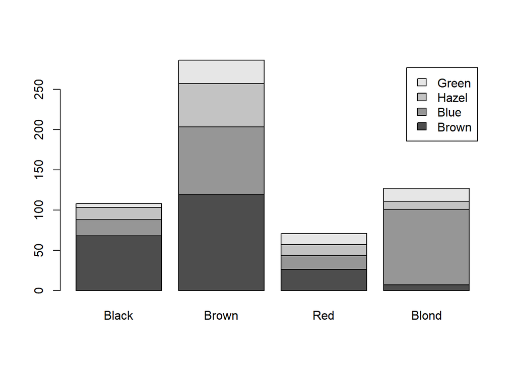

```r
barplot(hec, beside = FALSE, legend = TRUE)
```

`beside`를 `FALSE`로 지정할 경우, 앞선 결과와 달리 한 막대안에 모든 정보가 들어가는 것을 확인할 수 있다.

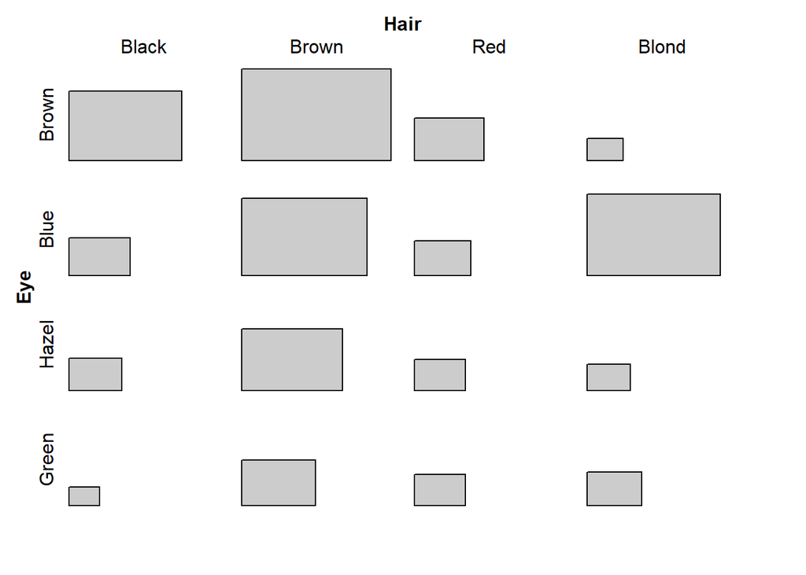

```r
library(vcd)
tile(hec)
```

`tile` 함수는 분할표가 갖고있는 데이터의 빈도를 매트릭스 형태로 시각화를 진행하여 변수간 관계를 조금 더 파악하기 쉽게 시각화 해주는 함수로, `vcd`패키지안에 포함돼있다.  
- `tile(data)`

- data: tile을 통해 빈도를 시각화하고자 하는 데이터

*Example 4.3: Mental impairment and parents’SES*

```r
data("Mental",package = "vcdExtra")
head(Mental)
```

```
##   ses   mental Freq
## 1   1     Well   64
## 2   1     Mild   94
## 3   1 Moderate   58
## 4   1 Impaired   46
## 5   2     Well   57
## 6   2     Mild   94
```

`Mental`데이터는 6x4의 분할표 형태로, 1660명의 젊은 뉴욕 거주자의 정신건강 상태를 부모의 사회 경제적 상태에 따른 빈도를 나타낸 데이터로, `vcdExtra`패키지 안에 포함돼있다.

- ses: 부모의 사회 경제적상태 (Factor variable - 1<2<3<4<5<6)
- mental: 정신건강 상태 (Factor variable - Well<Mild<Moderate<Impaired)
- freq: 빈도 (Discrete variable)

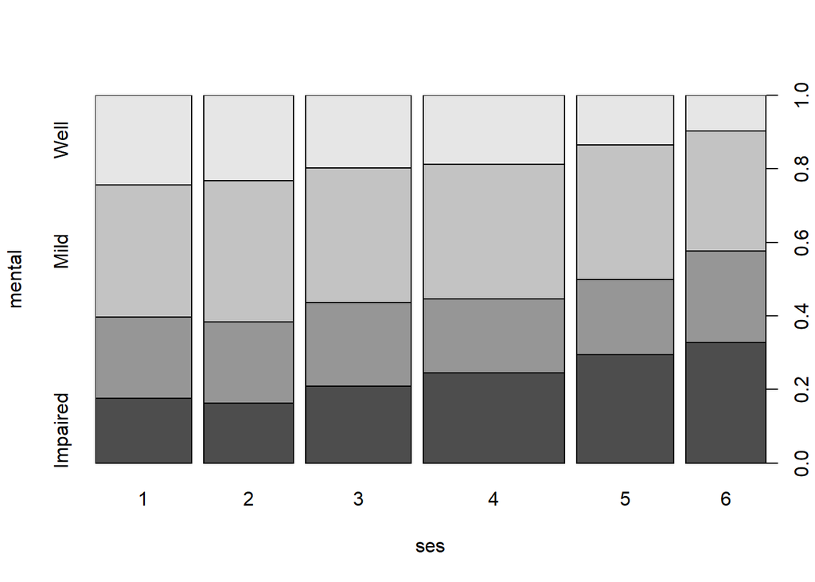

```r
mental <- xtabs(Freq ~ ses +mental, data = Mental)
spineplot(mental)
```

`spineplot`은 누적된 막대 그림의 일반화로 볼 수 있으며, 위의 코드에서는 **ses와 mental**에 따른 빈도를 시각화하기 위해 사용하였다.  
- `spineplot(data)`

- data: 누적된 막대 그림을 그리고자 하는 데이터 (일반적으로 교차표의 형태)

`spineplot`을 통해 `Mental`데이터의 누적 barchart를 확인할 수 있으며, 각 막대의 너비는 `SES`변수의 백분율에 비례한다.  
위의 그림을 통해 사회적 지위가 변함에 따라 **mental == Well**인 상태는 점점 감소하며, **mental == Impaired**인 상태는 점점 증가하는 것을 확인할 수 있다.

## 4.2 Tests of association for two-way tables

### 4.2.1 Notation and terminology

각 관측값이 일부 모집단에서 랜덤하게 추출되어 두 범주형 변수 A와 B로 나눠지는 경우, 이 변수들의 **joint distribution**을 참조하고 i번째 행, j번째 행으로 분류될 확률을 나타낸다.

**marginal distribution**은 joint distribution의 행과 열의 합으로 정의된다.

```r
Berkeley <- margin.table(UCBAdmissions,2:1)
library(gmodels)
CrossTable(Berkeley, prop.chisq = FALSE, prop.c = FALSE,
           format = "SPSS")
```

```
##
##    Cell Contents
## |-------------------------|
## |                   Count |
## |             Row Percent |
## |           Total Percent |
## |-------------------------|
##
## Total Observations in Table:  4526
##
##              | Admit
##       Gender | Admitted  | Rejected  | Row Total |
## -------------|-----------|-----------|-----------|
##         Male |     1198  |     1493  |     2691  |
##              |   44.519% |   55.481% |   59.456% |
##              |   26.469% |   32.987% |           |
## -------------|-----------|-----------|-----------|
##       Female |      557  |     1278  |     1835  |
##              |   30.354% |   69.646% |   40.544% |
##              |   12.307% |   28.237% |           |
## -------------|-----------|-----------|-----------|
## Column Total |     1755  |     2771  |     4526  |
## -------------|-----------|-----------|-----------|
##
##
```

`gmodels`패키지는 모델 적합 혹은 모델 적합 전 데이터를 살펴보기 위해 필요한 다양한 함수를 제공하는 패키지이다.

`Crosstable`은 SAS Proc 형태의 유사한 출력을 가진 교차 테이블 함수로 각 열과 행, Row & column, Total에 대한 Frequency와 proportion을 구할 수 있다. - `Crosstable(data,prop.chisq,prop.c,format)`

- data: 교차 테이블 함수를 적용할 데이터
- prop.chisq: 교차표에 카이제곱 검점 통계량 출력여부 (TRUE = 출력, FALSE = 출력 X)
- prop.c: 교차표에 열의 속성 추가여부 (TRUE = 출력, FALSE = 출력 X)
- format: 출력형식의 포맷 (“SPSS”, “SAS”)

### 4.2.2 2 by 2 tables: Odds and odds ratios

**연관성 측도**는 변수 간의 연관 정도를 나타내는 데 사용된다.  
특히 **odds ratio**는 2x2 표에서 특히 유용하며, 후에 설명되는 몇몇의 그래픽과 모델에서의 기본적인 매개변수이다.

이항 변수에서, 성공확률을 $\pi$라고 할 때, 성공의 **odds**는 다음과 같이 정의 된다.

$$odds = { \pi \over (1-\pi)}$$

따라서, odds가 1이라는 것은 $\pi$가 0.5이거나 성공과 실패 확률이 같다.

예를들어, $\pi$ = 0.75일 때, odds는 3(0.75 / 0.25)이므로 성공 확률은 실패의 3배라는 것을 알 수 있다.

성공의 오즈는 1을 중심으로 곱셈적으로 변하며, 로그를 취하면 **log odds** 또는 **logit**으로 불리는 측정값을 얻을 수 있다.

$$logit(\pi) = log(odds) = log { \pi \over (1-\pi)}$$

```r
P <- c(0.05, 0.1, 0.25, 0.5, 0.75, 0.9, 0.95)
odds <- P / (1-P)
logodds <- log(odds)
data.frame(P, odds, logodds)
```

```
##      P        odds   logodds
## 1 0.05  0.05263158 -2.944439
## 2 0.10  0.11111111 -2.197225
## 3 0.25  0.33333333 -1.098612
## 4 0.50  1.00000000  0.000000
## 5 0.75  3.00000000  1.098612
## 6 0.90  9.00000000  2.197225
## 7 0.95 19.00000000  2.944439
```

여러 성공확률들을 가정하고 각 확률을 이용해 **odds와 logodds**를 구해보았다.  
성공확률이 높아질수록 오즈와 로그오즈 모두 점점 증가하는 형태를 보인다.

두 그룹에 대한 이항반응은 그룹 변수를 행으로 사용하여 2x2 테이블로 제공한다.  
$\pi$, $\pi2$를 각각 그룹1과 그룹2의 성공확률 이라고하자.  
두 그룹에 대한 오즈의 비율 즉 **odds ratio**는 다음과 같이 정의된다.

$$odds ratio = \theta = {odds1 \over odds2} = {\pi1/(1-\pi1) \over \pi2/(1-\pi2)
}$$

odds와 마찬가지로 odds ratio 또한 항상 0과 무한대의 범위 사이에 존재한다.  
$\theta$ = 1인 경우 성공과 실패의 분포는 두 그룹 모두에서 동일하며 반응변수는 그룹과 독립적이다.  
$\theta$ > 1인 경우, 그룹 1의 성공 확률이 더 높고 $\theta$ < 1인 경우, 그룹 2의 성공 확률이 더 높다고 해석할 수 있다.

*Example 4.5: Berkeley admissions*

```r
library(vcd)
data("UCBAdmissions")
UCB <- margin.table(UCBAdmissions,1:2)
(LOR <- loddsratio(UCB))
```

```
## log odds ratios for Admit and Gender
##
## [1] 0.6103524
```

`vcd`패키지의 `loddsratio`함수를 이용하여 (로그)오즈비를 간단하게 구할 수 있다.  
- `loodsratio(data,log)`

- data: (로그)오즈비를 구할 데이터 (단, 데이터는 2차원의 분할표의 형태로 구성되어야 한다.)
- log: 로그오즈비 적용 여부 (TRUE = 로그오즈비, FALSE = 오즈비)

```r
(OR <- loddsratio(UCB,log=FALSE))
```

```
##  odds ratios for Admit and Gender
##
## [1] 1.84108
```

`log = FALSE`를 지정함으로써 로그오즈비가 아닌 **오즈비**를 구한 것을 확인할 수 있다.  
위의 결과의 경우, 남성이 여성에 비해 합격할 오즈가 약 1.84배 정도 높은 것을 알 수 있다.

```r
summary(LOR)
```

```
##
## z test of coefficients:
##
##                               Estimate Std. Error z value  Pr(>|z|)
## Admitted:Rejected/Male:Female 0.610352   0.063893  9.5527 < 2.2e-16 ***
## ---
## Signif. codes:  0 '***' 0.001 '**' 0.01 '*' 0.05 '.' 0.1 ' ' 1
```

`summary`함수를 통해 단순히 오즈비의 결과뿐만 아니라 표준오차, 유의확률 등의 추가적인 정보를 얻을 수 있다.  
유의확률이 유의수준 0.05보다 작으므로 주어진 변수를 이용해 오즈비를 구하는 것은 유의한 분석임을 알 수 있다.

```r
confint(OR)
```

```
##                                  2.5 %   97.5 %
## Admitted:Rejected/Male:Female 1.624377 2.086693
```

```r
confint(LOR)
```

```
##                                   2.5 %    97.5 %
## Admitted:Rejected/Male:Female 0.4851243 0.7355805
```

`confint`함수를 이용하여 오즈비 혹은 로그오즈비의 95% 신뢰구간의 추정값 또한 구할 수 있다.

```r
fisher.test(UCB)
```

```
##
##  Fisher's Exact Test for Count Data
##
## data:  UCB
## p-value < 2.2e-16
## alternative hypothesis: true odds ratio is not equal to 1
## 95 percent confidence interval:
##  1.621356 2.091246
## sample estimates:
## odds ratio
##   1.840856
```

`fisher.test`를 통해 오즈비에 대한 가설검정을 진행할수도 있다.

- H0: 오즈비는 1이다.
- H1: 오즈비는 1이 아니다.

주어진 결과의 유의확률이 유의수준 0.05보다 작으므로 귀무가설을 기각한다.  
따라서, 주어진 데이터의 오즈비는 1이 아닌 것을 확인할 수 있다.

### 4.2.3 Larger tables: Overall analysis

two-way table에서는 `assocstats`함수를 이용하여 전반적인 연관성 테스트를 진행할 수 있다.

만약, 데이터셋이 2개의 요인보다 많은 경우 표 생성시 포함되지 않은 다른 요인은 무시된다.

하지만, 제외된 요인이 사용된 요인과 상호작용이 존재할수도 있으므로 확인하는 작업이 필요하다.

*Example 4.6: Arthritis treatment*

```r
data("Arthritis",package = "vcd")
Art <- xtabs(~Treatment + Improved, data = Arthritis)
Art
```

```
##          Improved
## Treatment None Some Marked
##   Placebo   29    7      7
##   Treated   13    7     21
```

`Arthritis`데이터의 **Improved, Treatment**변수를 이용하여 교차표를 생성하였다.

```r
round(100 * prop.table(Art, margin = 1), 2)
```

```
##          Improved
## Treatment  None  Some Marked
##   Placebo 67.44 16.28  16.28
##   Treated 31.71 17.07  51.22
```

`prop.table`함수를 이용하여 행을 기준으로 확률표를 생성하였다.

```r
assocstats(Art)
```

```
##                     X^2 df  P(> X^2)
## Likelihood Ratio 13.530  2 0.0011536
## Pearson          13.055  2 0.0014626
##
## Phi-Coefficient   : NA
## Contingency Coeff.: 0.367
## Cramer's V        : 0.394
```

`vcd`패키지의 `assocstats`함수를 이용하여 연관성 분석을 진행한다.

또한, LR방법, 피어슨검정 방법의 유의확률이 유의수준 0.05보다 모두 작으므로 귀무가설을 기각한다.  
따라서, **Improved, Treatment** 변수는 독립이 아니므로 서로 연관이 있다고 볼 수 있다.

### 4.2.4 Tests for ordinal variables

행 변수와 열 변수 중 하나 또는 둘 다 순서형인 경우 일반적인 카이제곱 검정을 사용하게 되면 다른 결과가 출력될수도 있는데, 이는 카이제곱 검정은 변수가 순서형 변수여도 명목형 변수로 가정하기 때문이다.  
따라서, 일반 연관성에 대한 검정보다 더 민감한 검정을 사용할 수 있다.

변수의 순서적 특성을 고려하는 경우 `vcdExtra`패키지의 `CMHtest`를 고려해볼 수 있다.  
`CMHtest`는 분할표에 순서형 요인이 있는 경우의 연관성에 대한 검정을 진행할 때 사용한다. 이 검정은 기본적으로 순서형 요인에 숫자 점수를 할당하여 검정을 진행하게 된다.  
- `CMHtest(data)`

- data: 순서형 요인이 포함된 분할표

*Example 4.7: Mental impairment and parents’SES*

```r
data("Mental",package = "vcdExtra")
mental <- xtabs(Freq ~ ses + mental, data = Mental)
assocstats(mental)
```

```
##                     X^2 df   P(> X^2)
## Likelihood Ratio 47.418 15 3.1554e-05
## Pearson          45.985 15 5.3458e-05
##
## Phi-Coefficient   : NA
## Contingency Coeff.: 0.164
## Cramer's V        : 0.096
```

두 요인을 명목형 변수로 가정하고 `assocstats`함수를 통해 독립성 검정을 진행한 결과, 유의확률이 유의수준 0.05보다 작으므로 귀무가설을 기각한다.  
따라서, 두 요인은 서로 독립이 아니며 연관성이 있는 변수임을 알 수 있다.

```r
library("vcdExtra")
CMHtest(mental)
```

```
## Cochran-Mantel-Haenszel Statistics for ses by mental
##
##                  AltHypothesis  Chisq Df       Prob
## cor        Nonzero correlation 37.156  1 1.0907e-09
## rmeans  Row mean scores differ 40.297  5 1.3012e-07
## cmeans  Col mean scores differ 40.666  3 7.6971e-09
## general    General association 45.958 15 5.4003e-05
```

**Nonzero correlation**: 행 변수와 열변수가 모두 순서형일 경우, 두 변수에 점수를 할당하고 상관계수를 계산하여 Spearman의 순위 상관계수를 얻을 수 있다. 이 검정은 행 평균 점수가 행에 걸쳐 선형적으로 변화하는 패턴에 가장 민감하다.

**Row mean scores differ**: 만일 열 변수가 순서형인 경우 열 변수에 점수를 할당하면 각 행에 대한 평균이 생성된다. 행 변수와 열 변수의 연관성은 표의 행에 대해 평균이 다른지 여부를 검정하는 것으로 나타낼 수 있다. 이는 Kruskal-Wallis 비모수 검정과 유사하다.

**Col mean scores differ**: Row mean scores differ과 유사하며 행 변수에 점수를 할당하는 것만 차이가 있다.

**General association**: 행 변수와 열 변수가 모두 순서형이 아닌 경우 유일한 대립 가설은 행 변수와 열 변수 사이에 연관성이 있다는 것이다. CMH 검정 통계량은 카이-제곱 및 우도비 카이-제곱과 유사하다.

`mental`데이터는 두 요인 모두 순서형 데이터이므로 **Nonzero correlation**을 통해 결과해석을 해야한다.  
자유도가 1, 카이제곱 검정통계량의 값은 37.1558, 유의확률은 0.05보다 매우 작은 값을 가지는 것을 확인할 수 있다. 이때, 유의확률은 명목형을 가정하고 독립성 검정을 진행한 유의확률보다 매우 작으므로 더 유의한 결과가 나오는 것을 알 수 있다.  
따라서, 두 요인을 순서형으로 고려하여 독립성 검정을 진행했을 때에도 두 변수는 서로 독립이아니며, 서로 연관성이 있는 것을 확인할 수 있다.

### 4.2.5 Sample CMH profiles

#### 4.2.5.1 General association

```r
row1 <- c(0,15,25,15,0)
row2 <- c(5,20,5,20,5)
row3 <- c(20,5,5,5,20)
cmhdemo1 <- rbind(row1,row2,row3)
rownames(cmhdemo1) <- c("a1","a2","a3")
colnames(cmhdemo1) <- c("b1","b2","b3","b4","b5")
cmhdemo1
```

```
##    b1 b2 b3 b4 b5
## a1  0 15 25 15  0
## a2  5 20  5 20  5
## a3 20  5  5  5 20
```

```r
CMHtest(cmhdemo1)
```

```
## Cochran-Mantel-Haenszel Statistics
##
##                  AltHypothesis  Chisq Df       Prob
## cor        Nonzero correlation  0.000  1 1.0000e+00
## rmeans  Row mean scores differ  0.000  2 1.0000e+00
## cmeans  Col mean scores differ 72.203  4 7.7767e-15
## general    General association 91.797  8 2.0062e-16
```

임의로 생성한 `cmhdemo1`에 대해서 `CMHtest`를 한 결과는 위와같다.  
이때, **Non-zero correlation**, **row mean scores differ**모두 카이제곱 값이 정확히 0인 것을 볼 수 있는데, 이는 행 평균이 모두 같기 때문이다.

```r
row_1 <- c(2,5,8,8,8)
row_2 <- c(2,8,8,8,5)
row_3 <- c(5,8,8,8,2)
row_4 <- c(8,8,8,5,2)
cmhdemo2 <- rbind(row_1,row_2,row_3,row_4)
rownames(cmhdemo2) <- c("a1","a2","a3","a4")
colnames(cmhdemo2) <- c("b1","b2","b3","b4","b5")
cmhdemo2
```

```
##    b1 b2 b3 b4 b5
## a1  2  5  8  8  8
## a2  2  8  8  8  5
## a3  5  8  8  8  2
## a4  8  8  8  5  2
```

```r
CMHtest(cmhdemo2)
```

```
## Cochran-Mantel-Haenszel Statistics
##
##                  AltHypothesis  Chisq Df      Prob
## cor        Nonzero correlation 10.639  1 0.0011071
## rmeans  Row mean scores differ 10.676  3 0.0136127
## cmeans  Col mean scores differ 11.401  4 0.0224082
## general    General association 13.400 12 0.3406368
```

다시 한 번 임의로 생성한 `cmhdemo2`에 대해서 `CMHtest`를 진행해 보았다.

`cmhdemo2` 분할표는 약하고 유의하지 않은 일반 연관성이 포함되어 있지만 행과 열의 평균은 모두 유의하다.  
**General association** 결과에서는 유의확률이 유의수준 0.05보다 크므로 연관성이 존재하지 않는다는 결론으로 이어지지만, 순서형 요인을 고려한 검정(**Nonzero correlation**)에서는 유의확률이 유의수준 0.05보다 작으므로 연관성이 존재한다는 결론으로 이어진다.

이를 통해 변수간의 독립성 검정이 요인 수준의 순서 특성에 따라 달라진다고 생각 될 때는 순서형 요인에대한 보다 집중적인 검정을 진행하며, 순서형 요인의 수준을 숫자 점수값으로 재코딩 하는 것도 하나의 방법이 될 수 있다.

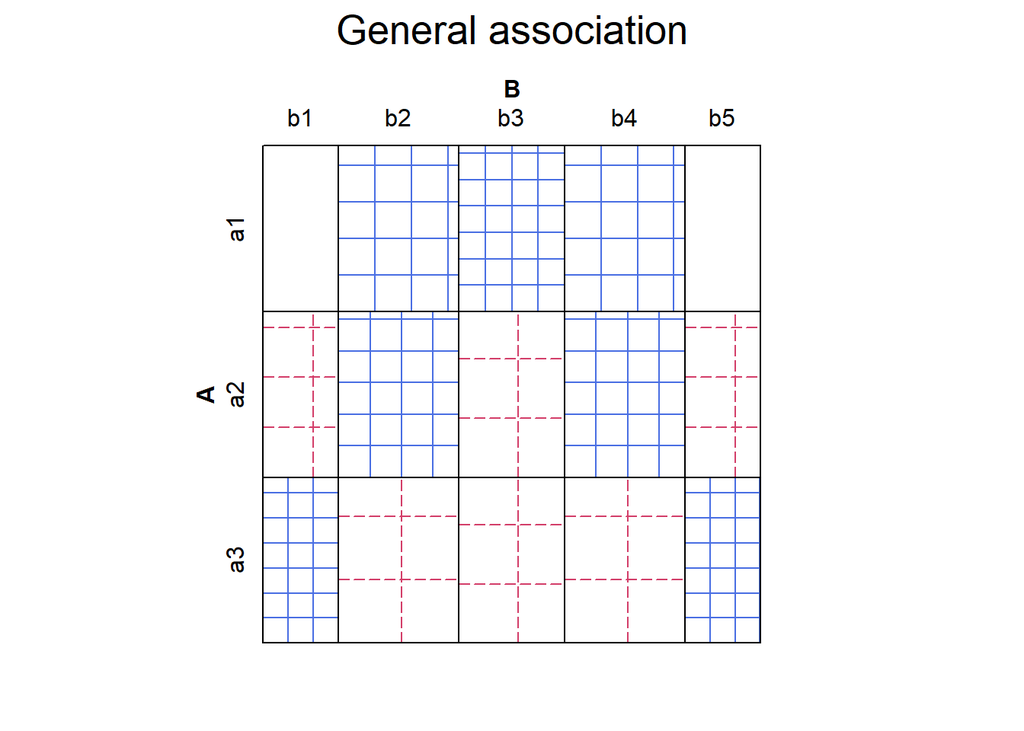

```r
sieve(cmhdemo1,shade = TRUE, main = "General association")
```

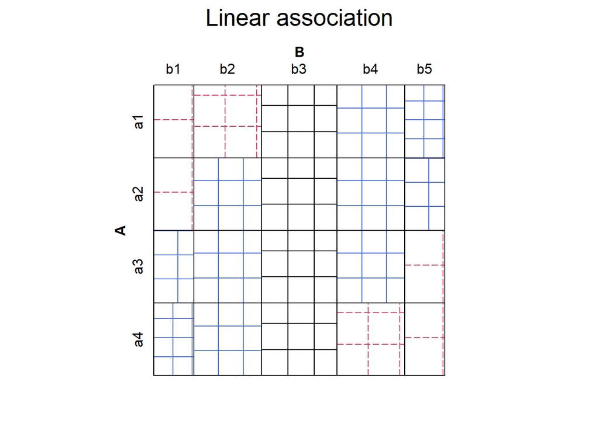

```r
sieve(cmhdemo2,shade = TRUE, main = "Linear association")
```

`sieve`함수는 이원 분할표의 관찰빈도와 기대빈도를 서로 비교할 수 있게 하는 **sieve diagram**을 시각화 할 수 있도록 도와주는 함수로, `vcd`패키지에 포함돼있다.  
- `sieve(data,labeling,shade)`

- data: sieve diagram을 그리고자 하는 데이터 (이원 분할표의 형태여야 한다.)
- labeling: 교차표위에 출력하고자 하는 값
- shade: 양의 잔차와 음의 잔차를 음영으로 구분할지에 대한 여부 (TRUE = 구분, FALSE = 구분 X)

**sieve diagram**을 통해 시각적으로 연관성을 살펴볼수도 있다.

## 4.3 Stratified analysis

### 4.3.1 Computing strata-wise statistics

**Stratified analysis(계층화 분석)**은 하나 이상의 배경 변수의 효과를 제어하여 분석하는 방법을 말한다.  
이는 분산 분석 설계에 블럭화 변수를 사용하는 것과 유사하다.

*Example 4.8: Arthritis treatment*

```r
Art2 <- xtabs(~Treatment + Improved + Sex, data = Arthritis)
Art2
```

```
## , , Sex = Female
##
##          Improved
## Treatment None Some Marked
##   Placebo   19    7      6
##   Treated    6    5     16
##
## , , Sex = Male
##
##          Improved
## Treatment None Some Marked
##   Placebo   10    0      1
##   Treated    7    2      5
```

**계층화 분석**을 `Arthritis`데이터에 적용하기 위해 `xtabs`함수를 사용하여 **Improved, Treatment**변수에 대한 분할표를 성별에 따라 나눠주었다.

```r
assocstats(Art2)
```

```
## $`Sex:Female`
##                     X^2 df  P(> X^2)
## Likelihood Ratio 11.731  2 0.0028362
## Pearson          11.296  2 0.0035242
##
## Phi-Coefficient   : NA
## Contingency Coeff.: 0.401
## Cramer's V        : 0.438
##
## $`Sex:Male`
##                     X^2 df P(> X^2)
## Likelihood Ratio 5.8549  2 0.053532
## Pearson          4.9067  2 0.086003
##
## Phi-Coefficient   : NA
## Contingency Coeff.: 0.405
## Cramer's V        : 0.443
```

**Contingency Coeff,Cramer’s V**는 남성, 여성 그룹에서 약 0.4의 값을 가지며, 어느정도 연관성이 있는 것 처럼 보인다.  
하지만, **여성의 유의확률은 유의수준 0.05보다 작아** 변수간 연관이 있다라는 결론을 얻을 수 있는 반면, **남성의 유의확률은 유의수준 0.05보다 크므로** 변수간 연관이 없다라는 결론을 얻을 수 있다.

```r
CMHtest(Art2)
```

```
## $`Sex:Female`
## Cochran-Mantel-Haenszel Statistics for Treatment by Improved
##  in stratum Sex:Female
##
##                  AltHypothesis  Chisq Df       Prob
## cor        Nonzero correlation 10.935  1 0.00094361
## rmeans  Row mean scores differ 10.935  1 0.00094361
## cmeans  Col mean scores differ 11.105  2 0.00387828
## general    General association 11.105  2 0.00387828
##
##
## $`Sex:Male`
## Cochran-Mantel-Haenszel Statistics for Treatment by Improved
##  in stratum Sex:Male
##
##                  AltHypothesis  Chisq Df     Prob
## cor        Nonzero correlation 3.7128  1 0.053997
## rmeans  Row mean scores differ 3.7128  1 0.053997
## cmeans  Col mean scores differ 4.7105  2 0.094871
## general    General association 4.7105  2 0.094871
```

`CMHtest`를 사용한 결과, **여성의 경우** 4가지 방법을 적용했을 때, 모든 유의확률이 유의수준 0.05보다 작아 변수 간 연관성이 있는 것을 확인할 수 있지만, **남성의 경우** 4가지 방법을 적용했을 때, 모든 유의확률이 유의수준 0.05보다 크므로 변수간 연관성이 없다. 앞선 결과와 동일한 결과가 나오는 것을 알 수 있다.

```r
apply(Art2, 3, sum)
```

```
## Female   Male
##     59     25
```

이러한 결과는 표본의 영향을 받을수도 있으므로 표본을 확인해본 결과, 여성이 남성보다 두 배 이상 표본이 많은 것을 확인할 수 있었다.  
따라서, 남성의 경우 표본을 늘린 후 연관성 검정을 다시 진행해보면 결과가 바뀔수도 있다는 추측을 해볼 수 있다.

### 4.3.2 Assessing homogeneity of association

계층화 분석에서 주 테이블 변수 간의 연관성이 모든 계층에서 동일한지 확인하는 것은 중요하다.  
2 x 2표의 경우 모든 계층에서 승산비가 동일한지 여부를 통해 확인할 수 있다.

- H0: 모든 계층에서 승산비가 동일하다.
- H1: 모든 계층에서 승산비가 동일하지 않다.

`woolf_test`는 모든 계층에 대한 동질성 검정을 진행하는 함수로, `vcd`패키지에 포함돼있다.  
- `woolf_test(table)`

- table: 동질성 검정을 진행할 데이터 (계층의 갯수는 상관없지만 2x2의 분할표 형태를 가져야 한다.)

*Example 4.9: Berkeley admissions*

```r
woolf_test(UCBAdmissions)
```

```
##
##  Woolf-test on Homogeneity of Odds Ratios (no 3-Way assoc.)
##
## data:  UCBAdmissions
## X-squared = 17.902, df = 5, p-value = 0.003072
```

`UCBAdmissions`데이터에 대한 동질성 검정 결과, 유의확률은 유의수준 0.05보다 작으므로 귀무가설을 기각한다.  
따라서, 승산비가 계층에 따라 동일하지 않은 것을 확인할 수 있다.

*Example 4.10: Arthritis treatment*

```r
woolf_test(Art2)
```

```
##
##  Woolf-test on Homogeneity of Odds Ratios (no 3-Way assoc.)
##
## data:  Art2
## X-squared = 0.31808, df = 1, p-value = 0.5728
```

`Art2`데이터에 대한 동질성 검정 결과, 유의확률은 유의수준 0.05보다 크므로 귀무가설을 기각하지 못한다.  
따라서, 승산비가 계층에 따라 동일한 것을 확인할 수 있다.

```r
library(MASS)
loglm(~ (Treatment + Improved +Sex)^2, data =Art2)
```

```
## Call:
## loglm(formula = ~(Treatment + Improved + Sex)^2, data = Art2)
##
## Statistics:
##                       X^2 df  P(> X^2)
## Likelihood Ratio 1.703663  2 0.4266329
## Pearson          1.133571  2 0.5673463
```

## 4.4 Fourfold display for 2 x 2 tables

**Fourfold display**는 2x2 표의 표시를 위해 만들어진 방사형 다이어그램이다.  
각각의 셀의 빈도는 $\sqrt{n_{ij}}$에 비례하는 1/4 circle로 표시되며, 면적은 셀의 빈도에 비례한다.  
이 그림의 목적은 샘플 odds ratio를 표시하는 것이다. 변수 사이의 연관성이 있다면, 한 방향의 대각선 반대쪽 셀과 크기가 다른 셀 크기가 다른 경향으로 나타나며 색깔 또는 음영을 통해 방향을 표시한다.

R에서 `Fourfold`함수는 `vcd`패키지안에 포함돼있다.  
- `Fourfold(data)`

- data: Fourfold 함수를 적용할 데아터 (분할표의 계층은 상관없지만 반드시 2x2형태의 분할표이어야 한다.)

*Example 4.11: Berkeley admissions*

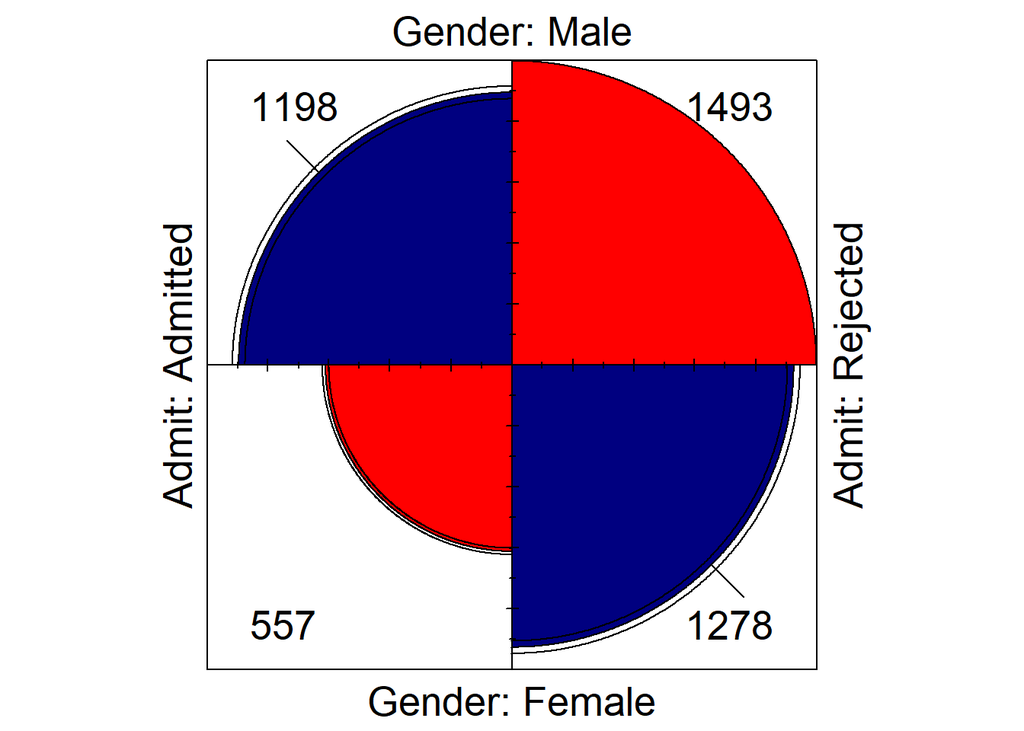

```r
fourfold(Berkeley, std = "ind.max") # unstandardized
```

위 그림은 표준화 되지않은 fourfold display를 보여준다. 여기서, 각 사분면의 점은 각 모서리에 숫자로 표시된 셀 빈도에 비례한다.  
승산비는 어두운 음영 영역의 곱에 비례하며, 밝은 음영 영역의 곱으로 나눈다.  
위의 그림을 통해 남성이 합격할 오즈가 여성에 비해 **약 2배 정도 높다**는 것을 쉽게 확인할 수 있다.

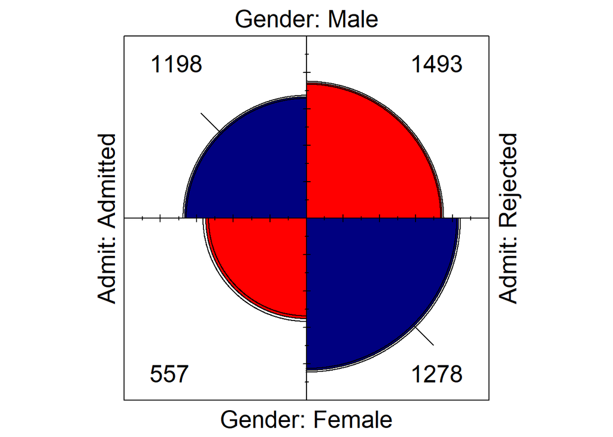

```r
fourfold(Berkeley, margin = 1) # equating gender
```

첫번째 그림을 보면 남성과 여성의 표본 차이가 크기 때문에 면적 차이가 큰 것을 볼 수 있다.  
이 문제를 해결하기 위해 위의 그림은 행 백분율에 비례하도록 하여 fourfold display 그렸다.  
앞선 그림과 같이 남성이 합격할 오즈가 여성보다 2배정도 높은 것을 알 수 있다.  
불합격할 오즈는 남성과 여성 모두 큰 차이가 없을을 확인할 수 있다.

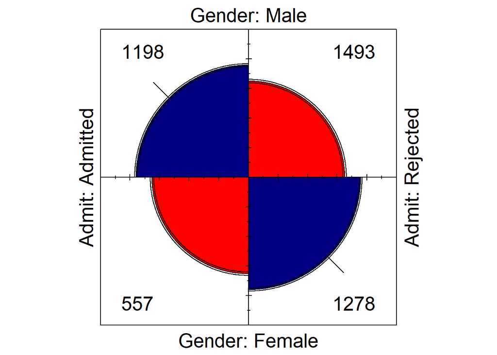

```r
fourfold(Berkeley)
```

표준화를 통해, 신뢰 고리는 승산비가 1과 다르지 않을 경우 각 상단의 사분면에 대한 신뢰 고리와 그 아래의 신뢰 고리가 겹치는 특성을 갖는다.  
일반적으로 가장 유용한 형태인 **완전히 표준화된 fourfold display**는 위 그림과 같다.

### 4.4.1 Confidence rings for oods ratio

```r
summary(loddsratio(Berkeley))
```

```
##
## z test of coefficients:
##
##                               Estimate Std. Error z value  Pr(>|z|)
## Male:Female/Admitted:Rejected 0.610352   0.063893  9.5527 < 2.2e-16 ***
## ---
## Signif. codes:  0 '***' 0.001 '**' 0.01 '*' 0.05 '.' 0.1 ' ' 1
```

`Berkeley`데이터의 로그 오즈비를 구한 결과 약 0.6103이 나온 것을 확인할 수 있다.

```r
exp(.6103 + c(-1,1) * qnorm(0.975) * 0.06398)
```

```
## [1] 1.624015 2.086939
```

로그 오즈비를 구했기 때문에 `exp`함수를 통해 로그를 제거하고 오즈비에 대한 신뢰구간을 구한다.  
`Berkeley`데아터의 95%오즈비 신뢰구간은 (1.624,2.087)인 것을 확인할 수 있다.

```r
confint(loddsratio(Berkeley, log = FALSE))
```

```
##                                  2.5 %   97.5 %
## Male:Female/Admitted:Rejected 1.624377 2.086693
```

직접 계산하지 않고 `confint`함수를 사용하여 오즈비의 신뢰구간을 간편하게 얻을수도 있다.

### 4.4.2 Stratified analysis for 2x2xk tables

2x2xk 테이블에서 마지막 차원은 종종 **계층**에 해당되며, 일반적으로 첫 번째 두 번째 변수 사이의 연관성이 계층 간에 동일한지 확인하는 것은 중요한 문제 중 하나이다.

#### 4.4.2.1 Stratified display

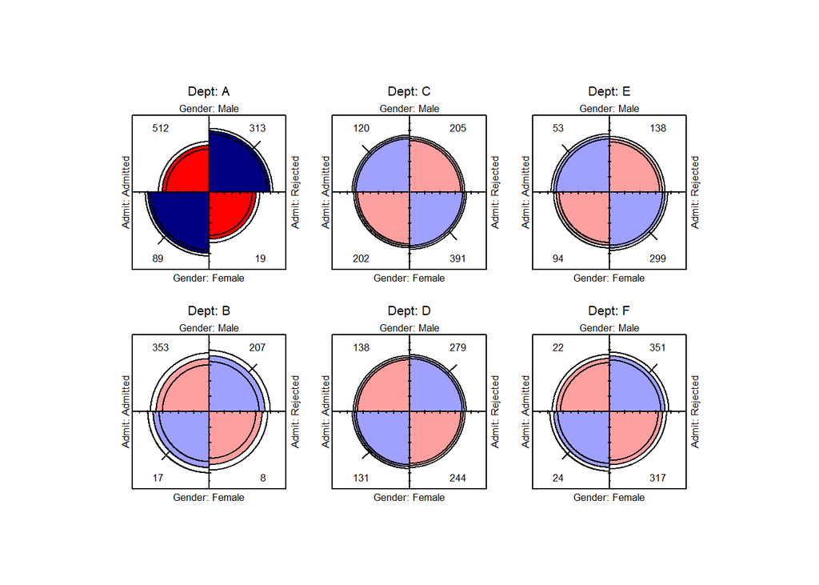

```r
UCB <- aperm(UCBAdmissions, c(2,1,3))
fourfold(UCB, mfrow = c(2,3))
```

`UCBAdmissions`의 6개의 학과를 고려하여 `Fourfold`그림을 그려보았다. A학과를 제외하고 나머지 학과들의 `Fourfold`면적은 거의 동일해 보이므로, 성별에 따른 입학 오즈비는 동일한 것을 알 수 있다.

```r
exp((loddsratio(UCB))$coefficients[1])
```

```
##        A
## 0.349212
```

부서 A는 다른 부서와 달리 남성이 입학할 오즈가 여성에 비해 약 0.34배인 것을 확인할 수 있다.  
즉, 여성이 남성에 비해 A부서에 입학할 오즈가 약 2.86배 정도 높은 것을 알 수 있다.

#### 4.4.2.2 Visualization principles for complex data

크고 복잡한 데이터에서 중요한 원칙은 통제된 비교이다. `fourfold`는 세그먼트의 각도를 일정하게 유지하고 반지름을 변화 시킨다는 점에서 파이 차트와 다르다.  
중요한 결과는 표의 해당 셀이 항상 동일한 위치에 있기 때문에 서로 다른 층에 대한 `fourfold`를 쉽게 비교할 수 있다.

*Example 4.12: Breathlessness and wheeze in coal miners*

```r
data("CoalMiners", package = "vcd")
head(CoalMiners)
```

```
## , , Age = 20-24
##
##               Wheeze
## Breathlessness    W  NoW
##            B      9    7
##            NoB   95 1841
##
## , , Age = 25-29
##
##               Wheeze
## Breathlessness    W  NoW
##            B     23    9
##            NoB  105 1654
##
## , , Age = 30-34
##
##               Wheeze
## Breathlessness    W  NoW
##            B     54   19
##            NoB  177 1863
##
## , , Age = 35-39
##
##               Wheeze
## Breathlessness    W  NoW
##            B    121   48
##            NoB  257 2357
##
## , , Age = 40-44
##
##               Wheeze
## Breathlessness    W  NoW
##            B    169   54
##            NoB  273 1778
##
## , , Age = 45-49
##
##               Wheeze
## Breathlessness    W  NoW
##            B    269   88
##            NoB  324 1712
##
## , , Age = 50-54
##
##               Wheeze
## Breathlessness    W  NoW
##            B    404  117
##            NoB  245 1324
##
## , , Age = 55-59
##
##               Wheeze
## Breathlessness    W  NoW
##            B    406  152
##            NoB  225  967
##
## , , Age = 60-64
##
##               Wheeze
## Breathlessness    W  NoW
##            B    372  106
##            NoB  132  526
```

`CoalMiners`데이터는 방사선 증거가 없는 20~64세의 흡연자인 석탄 광부들의 두 폐 질환 즉, 호흡과 휘즈 사이의 연관성에 대한 정보를 제공하는 데이터로 `vcd`패키지안에 포함돼있다.

- Breathlessness: 호흡 (Factor variable - B, NoB)
- wheeze: 휘즈 (Factor variable - W, NoW)
- Age: 나이 (Factor variable - 20<sub>24,25</sub>29,…,60~64)

```r
CM <- CoalMiners[, , 2:9]
structable(.~Age, data = CM)
```

```
##       Breathlessness    B       NoB
##       Wheeze            W  NoW    W  NoW
## Age
## 25-29                  23    9  105 1654
## 30-34                  54   19  177 1863
## 35-39                 121   48  257 2357
## 40-44                 169   54  273 1778
## 45-49                 269   88  324 1712
## 50-54                 404  117  245 1324
## 55-59                 406  152  225  967
## 60-64                 372  106  132  526
```

인덱싱을 통해 `CoalMiners`데이터의 필요한 부분만을 불러오고 `Structable`을 통해 여러개의 계층으로 구성돼있는 분할표를 한 눈에 살펴볼 수 있게 하였다.

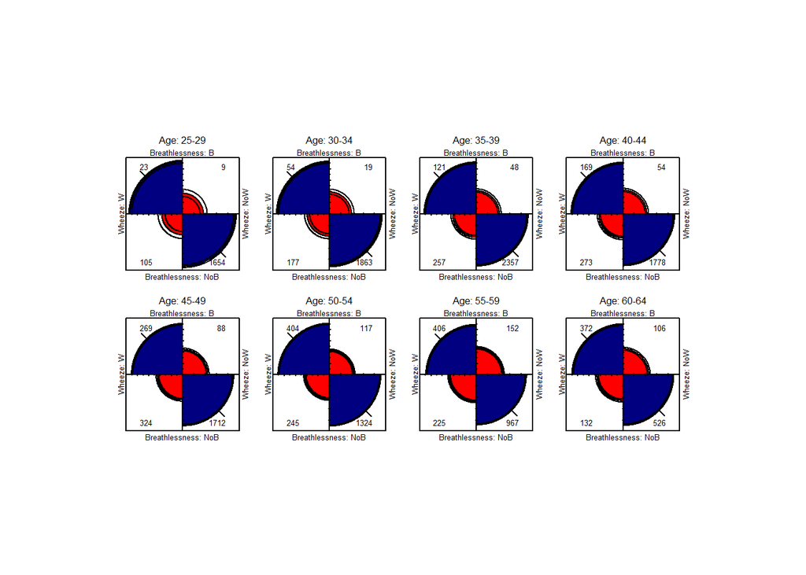

```r
fourfold(CM, mfcol = c(2,4))
```

`fourfold`를 통해 대략적인 오즈비를 살펴본 결과, 거의 모든 변수의 수준에서 유의한 오즈비 차이가 있는 것을 확인할 수 있었다.

```r
loddsratio(CM)
```

```
## log odds ratios for Breathlessness and Wheeze by Age
##
##    25-29    30-34    35-39    40-44    45-49    50-54    55-59    60-64
## 3.695261 3.398339 3.140658 3.014687 2.782049 2.926395 2.440571 2.637954
```

`CoalMiners`데이터의 로그 오즈비를 구한 결과는 위와같다. 나이가 증가할수록 로그오즈비가 점차 감소하는 것을 볼 수 있다.

```r
loddsratio(CM,log = FALSE)
```

```
##  odds ratios for Breathlessness and Wheeze by Age
##
##    25-29    30-34    35-39    40-44    45-49    50-54    55-59    60-64
## 40.25608 29.91436 23.11908 20.38272 16.15208 18.66025 11.47959 13.98456
```

나이에 따른 호흡 곤란 한계와 동일한 휘즈에 대한 오즈비를 구해보았다(`log = FALSE`옵션 지정).  
`fourfold`와 위의 결과를 통해 나이가 증가할수록 호흡 곤란 한계와 휘즈에 대한 오즈비가 점차 낮아지는 것을 알 수 있다.

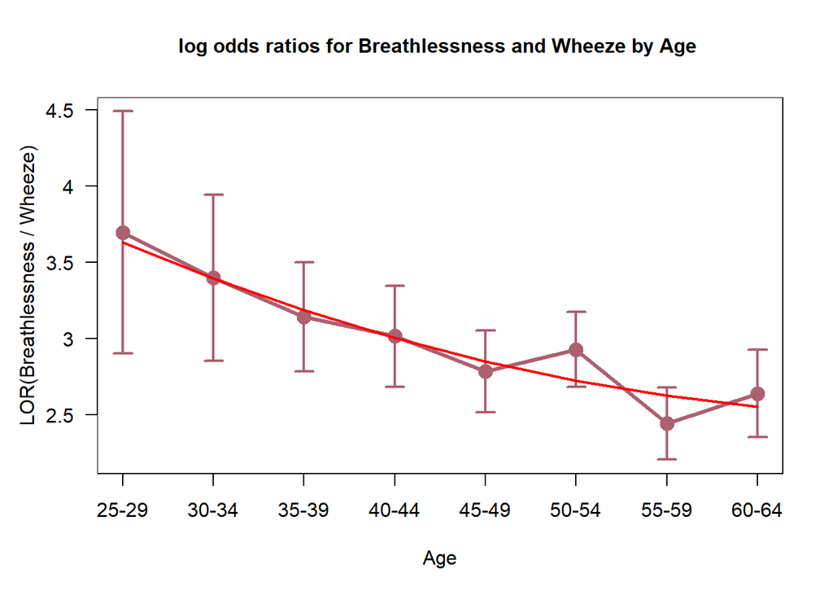

```r
lor_CM <- loddsratio(CM)
plot(lor_CM, bars = FALSE, baseline = FALSE,
     whiskers = .2)
lor_CM_df <- as.data.frame(lor_CM)
age <- seq(25,60,by=5) + 2
lmod <- lm(LOR ~ poly(age,2),weights = 1 / ASE^2,
           data = lor_CM_df)
grid.lines(seq_along(age),fitted(lmod),
           gp = gpar(col= "red", lwd = 2),
           default.units = "native")
```

분석 목적이 승산비가 계층화 요인에 따라 어떻게 변하는지 이해하는 것이라면 승산비를 직접 표시하는 것이 좋다.  
나이에 따른 호흡 곤란 한계와 휘즈의 로그오즈비 변화를 그림으로 살펴보았다.  
분석 결과를 통해 확인하는 것 보다 로그오즈비의 감소추세를 더 쉽게 파악할 수 있다.

```r
summary(lmod)
```

```
##
## Call:
## lm(formula = LOR ~ poly(age, 2), data = lor_CM_df, weights = 1/ASE^2)
##
## Weighted Residuals:
##        1        2        3        4        5        6        7        8
##  0.16169  0.01619 -0.24431  0.06266 -0.49715  1.61148 -1.52279  0.58509
##
## Coefficients:
##               Estimate Std. Error t value Pr(>|t|)
## (Intercept)    2.99531    0.07826  38.276 2.29e-07 ***
## poly(age, 2)1 -0.99773    0.25127  -3.971   0.0106 *
## poly(age, 2)2  0.17682    0.21712   0.814   0.4525
## ---
## Signif. codes:  0 '***' 0.001 '**' 0.01 '*' 0.05 '.' 0.1 ' ' 1
##
## Residual standard error: 1.058 on 5 degrees of freedom
## Multiple R-squared:  0.7816, Adjusted R-squared:  0.6942
## F-statistic: 8.944 on 2 and 5 DF,  p-value: 0.0223
```

## 4.5 Sieve diagrams

two-way table 혹은 더 높은 분할표에서는 합리적인 귀무가설을 하에서 **예상되는 빈도와 관찰된 빈도를 비교**해서 보여줘야 한다고 제안한다.  
이를 위해 분할표를 그래픽으로 표현하는 몇 가지 방법은 행과 열 변수가 독립적일 때, 측정된 기대 빈도 $m_{ij}$가 행과 열 합계의 곲(총합으로 나눠진다.)이라는 사실에 기초한다.

$$m_ij = { n_{i+}n_{+j} \over n_{++}}$$

그런 다음 각 셀은 관찰된 빈도, 예상 빈도 또는 편차를 직사각형으로 나타낼 수 있다.  
직사각형의 시각적 속성을 사용하여 연관 패턴을 강조할 수 있다.

### 4.5.1 Two-way tables

```r
haireye <- margin.table(HairEyeColor, 1:2)
expected = independence_table(haireye)
round(expected,1)
```

```
##        Eye
## Hair    Brown  Blue Hazel Green
##   Black  40.1  39.2  17.0  11.7
##   Brown 106.3 103.9  44.9  30.9
##   Red    26.4  25.8  11.2   7.7
##   Blond  47.2  46.1  20.0  13.7
```

`independence_table`은 분할표의 각 셀에 대한 기대빈도를 쉽게 구할 수 있게 만들어주는 함수로, `vcd`패키지안에 포함돼 있다.  
- `independence_table(table)`

- table: 기대빈도를 계산하고자 하는 분할표

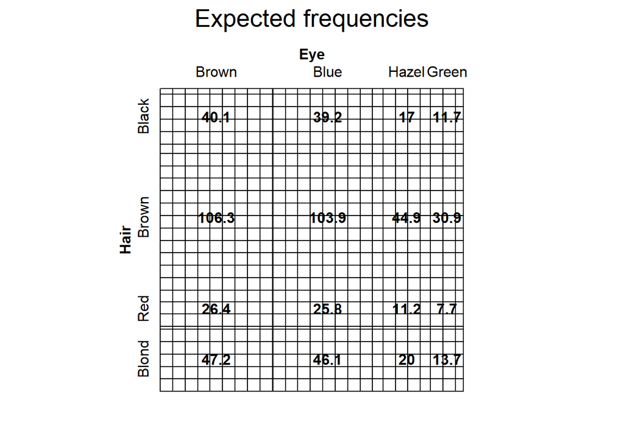

```r
sieve(expected,labeling=labeling_values,
      gp_text = gpar(fontface = 2),
      shade = TRUE,
      main = "Expected frequencies")
```

위의 그림은 만약 머리 색과 눈의 색이 독립적인 경우의 빈도를 나타낸다. 즉, 기대빈도를 출력한다고 이해할 수 있다.  
관찰된 빈도를 표시하기 위해 셀을 교차 해석하면 아래와 같이 관찰빈도와 기대빈도를 암묵적으로 비교하는 데이터 표시를 할 수 있다.  
이 원리를 바탕으로 위와 같은 그림을 **sieve diagram**이라고 한다.  
각 직사각형의 면적은 항상 기대 빈도에 비례하지만 관찰 빈도는 각 직사각형의 정사각형의 수로 표시된다.

**Eye = Brown, Hair = Brown**일때의 기대빈도가 106.3으로 가장 크고 **Eye = Green, Hair = Red**일때의 기대빈도가 7.7로 가장 작은 것을 확인할 수 있다.

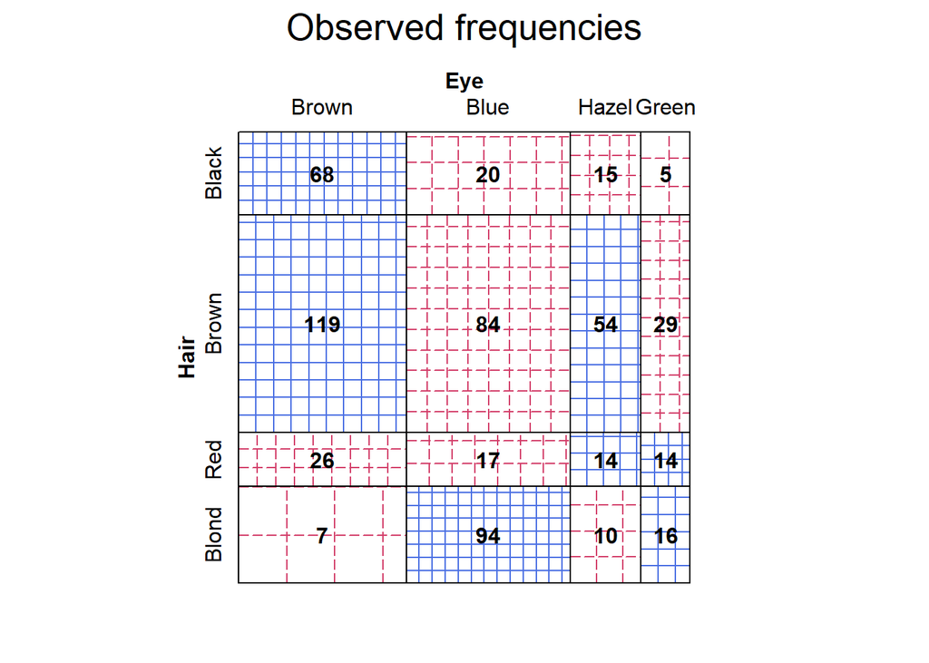

```r
sieve(haireye,labeling = labeling_values,
       gp_text = gpar(fontface = 2),
      shade = TRUE,
      main = "Observed frequencies")
```

관찰 빈도와 기대 빈도의 차이는 음영 밀도의 변화로 나타난다. 독립성으로부터 양수 및 음수 편차의 패턴은 음수 편차인 경우 빨간색, 양수인 경우 파란색을 사용하여 더 쉽게 확인할 수 있다.  
색상과 음영을 통해 위의 그림은 **Hair = Blond, Eye = Blue**, **Hair = Brown, Eye = Brown**인 사람들의 셀은 파란색을 가지므로 관찰빈도가 기대빈도보다 높은 것을 확인할 수 있다.  
**Hair = Brown, Eye = Blue**, **Hair = Brown, Eye = Green**인 사람들의 셀은 빨간색을 가지므로 관찰빈도가 기대빈도보다 낮은 것임을 확인할 수 있다.

*Example 4.14: Visual acuity*

```r
data("VisualAcuity", package = "vcd")
```

`VisualAcuity`데이터는 30-39세인 남성 3,242명과 여성 7,477명의 좌측 우측 시력을 나타낸 데이터로 `vcd`패키지 안에 포함돼 있다.

- Freq: 빈도 (Discrete variable)
- right: 우측시력 (Factor variable - 1,2,3,4)
- left: 좌측시력 (Factor variable - 1,2,3,4)
- gender: 성별 (Factor variable - female, male)

```r
VA <- xtabs(Freq ~ right + left + gender, data = VisualAcuity)
dimnames(VA)[1:2] <- list(c("high",2,3,"low"))
names(dimnames(VA))[1:2] <- paste(c("Right","Left"),"eye grade")
structable(aperm(VA))
```

```
##                        Left eye grade high    2    3  low
## gender Right eye grade
## male   high                            821  112   85   35
##        2                               116  494  145   27
##        3                                72  151  583   87
##        low                              43   34  106  331
## female high                           1520  266  124   66
##        2                               234 1512  432   78
##        3                               117  362 1772  205
##        low                              36   82  179  492
```

`VisualAcuity`데이터를 `xtabs`함수를 이용하여 성별을 계층으로하며, 빈도에따른 좌측시력,우측시력에 대한 교차표형태로 만들어 주었다.  
또한, 시력이 1인경우를 **high**, 시력이 4인 경우를 **low**로 재코딩하였고 `structable`를 사용하여 교차표를 쉽게 탐색할 수 있도록 하였다.

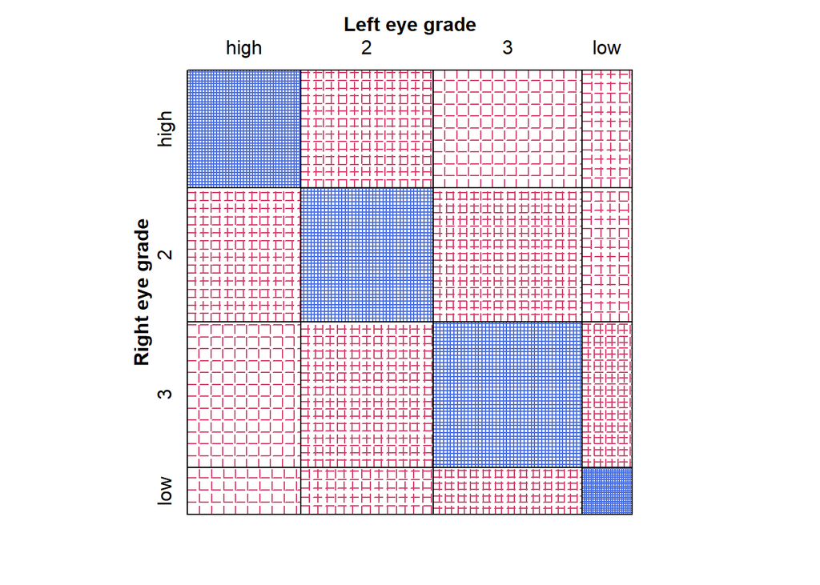

```r
sieve(VA[, , "female"], shade = TRUE)
```

`VisualAcuity`데이터 중, 성별이 여성인 경우의 `sieve diagram`을 그려보았다.  
대각선셀은 잔차의 색깔이 파란색이므로 양의 잔차에 해당되는데, 이는 여성의 경우 **왼쪽눈과 오른쪽눈의 시력이 같은 경향이 많다**는 것을 보여주며, 독립성이 강하게 결여된다는 증거이기도 하다.  
직사각형의 면적은 빈도에 비례하므로, **left = 3, right = 3**인 여성들의 면적이 가장 크므로 가장 많은 빈도를 갖고있음을 알 수 있다.

### 4.5.2 Larger tables: The strucplot framework

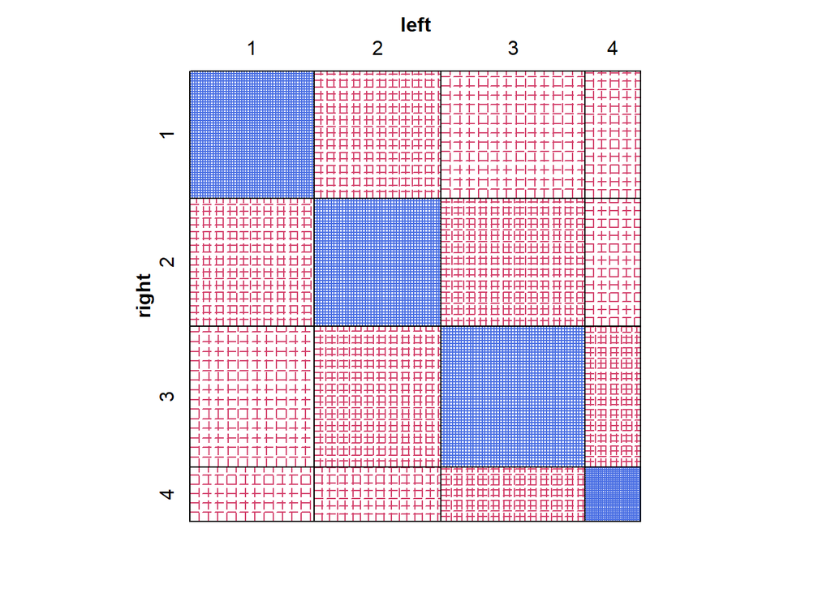

```r
sieve(Freq ~ right + left, data = VisualAcuity, shade = TRUE)
```

`sieve`함수는 다른 시각화 함수들과 같이 **formula method**를 통해서 원하는 변수들로 시각화를 진행할 수 있다.  
위의 예시는 빈도에 따른 왼쪽 및 오른쪽 눈의 시력을 통해 얻어진 교차표에 대한 `sieve diagram`이다.  
왼쪽 눈의 시력과 오른쪽 눈의 시력이 같은 사람들의 셀이 파란색이므로 관찰빈도가 기대빈도 보다 높음을 확인할 수 있고 이를 통해 한쪽 눈의 시력이 같으면 다른 쪽 눈의 시력이 같은 경향이 있음을 확인할 수 있다.

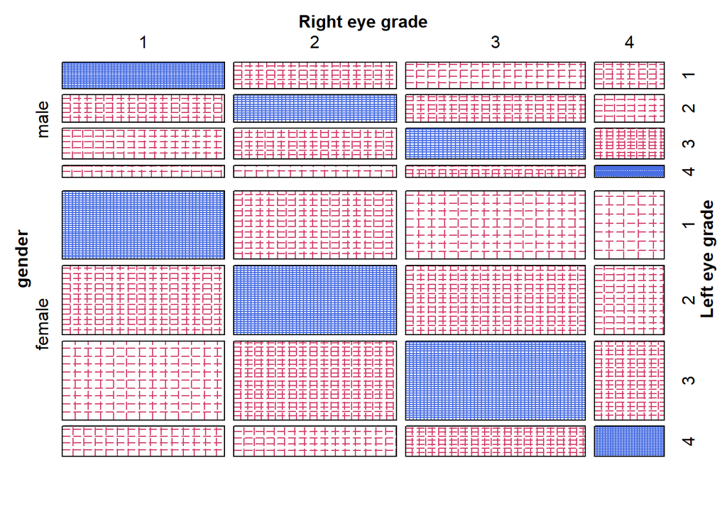

```r
sieve(Freq ~ right + left | gender, data = VisualAcuity,
      shade = TRUE, set_varnames = c(right = "Right eye grade", left = "Left eye grade"))
```

`| 표현`을 이용하여 원하는 변수를 계층으로 하는 `sieve diagram`그림을 볼 수도 있다. 위의 그림은 성별에 따라 구분한 `sieve diagram`이다.  
남성과 여성에 상관없이 양쪽눈의 시력이 같은 사람들이 기대빈도 보다 많이 관찰된 것을 확인할 수 있다.

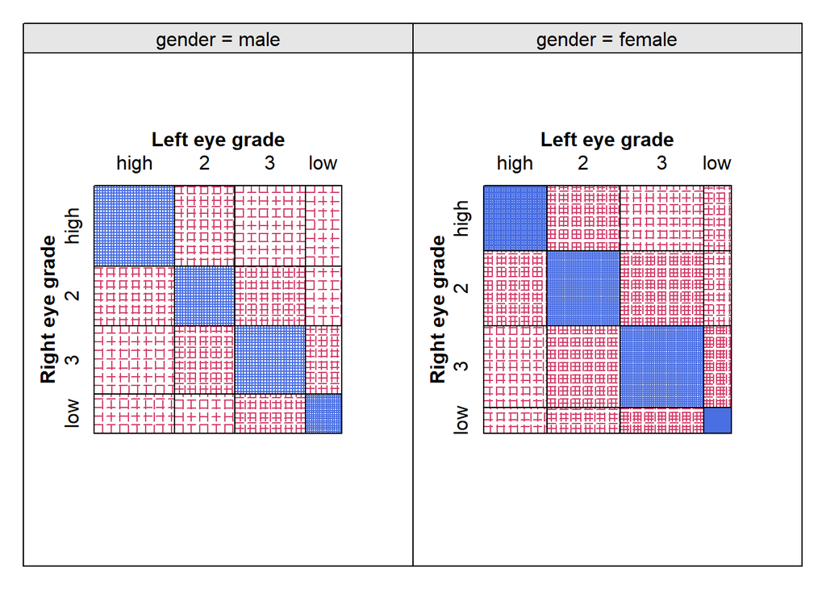

```r
cotabplot(VA, cond = "gender", panel = cotab_sieve,
          shade = TRUE)
```

`cotabplot`은 분할표가 주어졌을 때, 분할표의 **conditional plot**을 시각화하기 위한 함수로 `vcd`패키지안에 포함 돼 있다.  
- `cotabplot(table,cond,panel,shade)`

- table: **conditional plot**을 그리고자 하는 분할표
- cond: 계층변수
- panel: **conditional plot**의 유형
- shade: 잔차에 따른 음영 표시 여부

위의 그림은 `cotabplot`을 사용하여 성별에 따른 `sieve diagram`을 그린 결과이다.  
`cotabplot`은 `sieve`함수와 달리 계층에 따라 panel을 구분해주기 때문에 분할된 시각화 결과를 보고자 할때, 유용하게 사용할 수 있다.

*Example 4.15: Berkeley admissions*

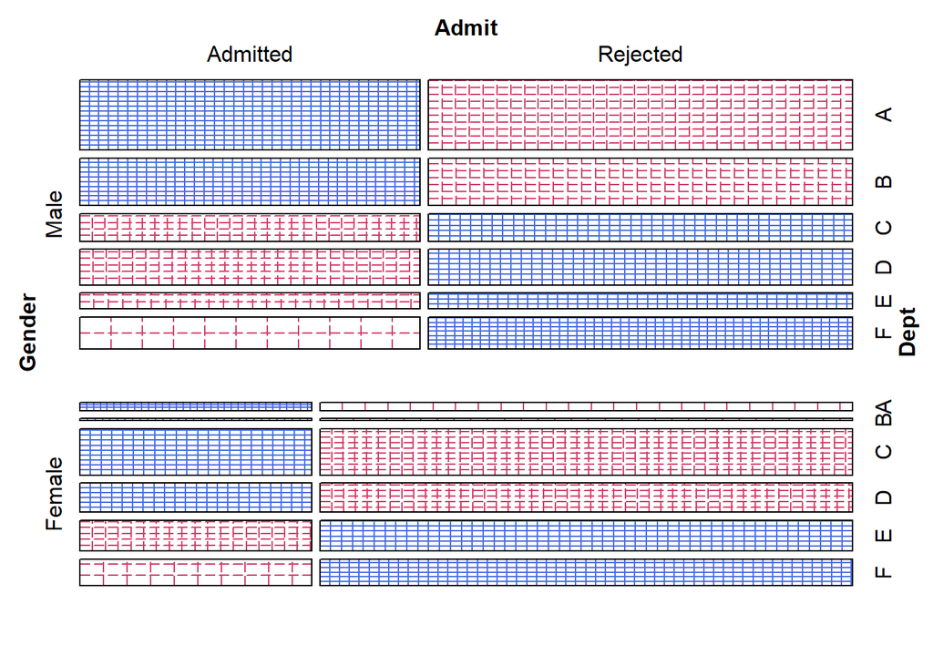

```r
sieve(UCBAdmissions, shade = TRUE, condvar = 'Gender')
```

위의 그림은 성별에 의해 조건화된 부서와 부서의 합격여부 관계에 대한 `sieve diagram`을 보여준다.  
전체적으로 여성보다 남성 지원자가 더 많았으며, 남성과 여성에 대해 파랑색(관찰빈도 > 기대빈도) 패턴이 비슷한 것을 알 수 있다.  
남성과 여성 모두 A,B부서에 대한 합격 관찰빈도는 기대빈도 보다 높고, E,F부서에 대한 불합격 관찰빈도가 기대빈도보다 높은 것을 확인할 수 있다.  
이를 통해, A,B부서는 전반적으로 합격률이 높지만 E,F부서는 합격률이 낮은 것을 알 수 있다.

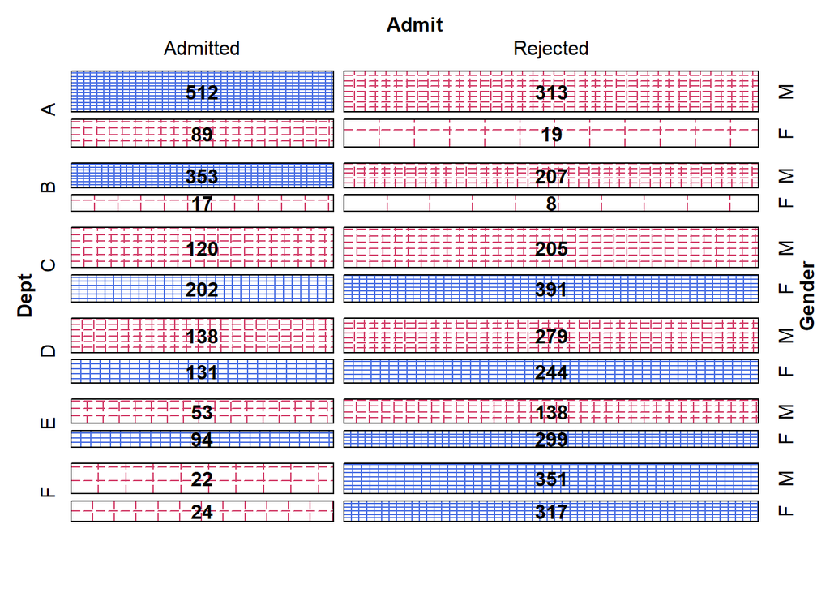

```r
sieve(~Dept + Admit + Gender, data = UCBAdmissions,
      shade = TRUE, labeling = labeling_values,
      gp_text = gpar(fontface = 2),
      abbreviate_labs = c(Gender = TRUE))
```

위의 그림은 `Dept`를 첫 번째 분할 변수로 만 든 후, 성별에 따른 합격여부를 `sieve diagram`그림으로 나타내었다.  
위의 formula는 세 변수를 모두 상호 독립을 가정하는데, 이럴 경우 여성의 A,B부서에 대한 합격요인이 음의 잔차가 되는 것을 확인할 수 있다. 이를 통해, 세 변수에 대해서 상호독립을 가정하는 것은 적절하지 않음을 확인할 수 있다.  
`labeling` 인수는 각 사각형의 셀 빈도를 표현하는데 사용되고, `gp_text`는 굵은 글꼴로 만들어주며, `abbreviate_labs`는 오버플롯을 피하기 위해 사용한다.

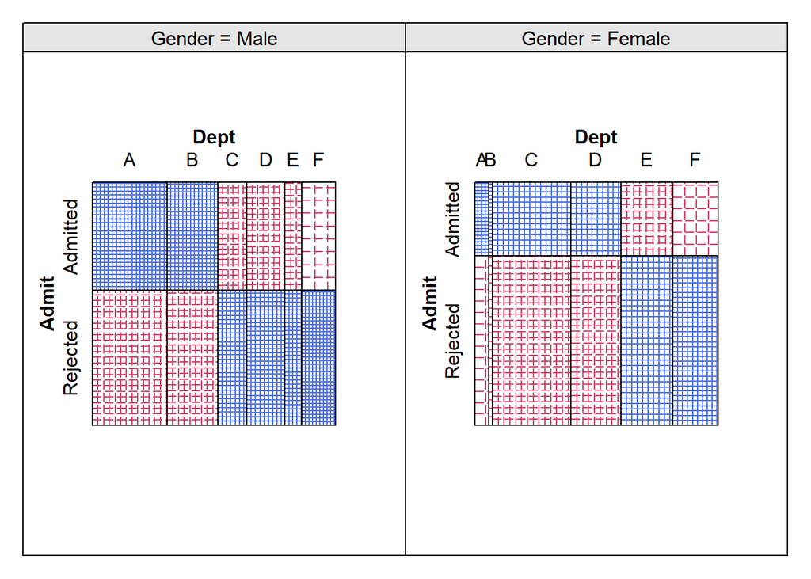

```r
cotabplot(UCBAdmissions, cond = "Gender",
          panel = cotab_sieve,
          shade = TRUE)
```

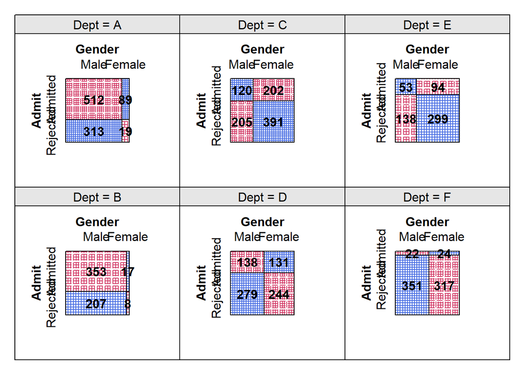

```r
cotabplot(UCBAdmissions, cond = "Dept",
          panel = cotab_sieve,
          shade = TRUE, labeling = labeling_values,
          gp_text = gpar(fontface=  "bold"))
```

`UCBAdmissions`의 데이터를 `cotabplot`을 통해 원하는 계층 변수에 따라 패널을 나누고 그에 따른 `sieve diagram`을 살펴볼 수 있다.

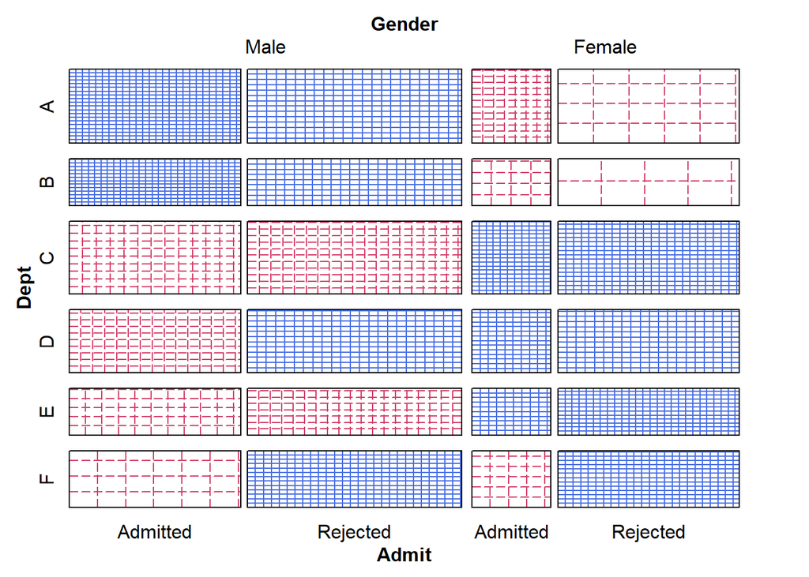

```r
UCB2 <- aperm(UCBAdmissions, c(3,2,1))
sieve(UCB2, shade = TRUE, expected = ~ Admit * Gender + Dept, split_vertical = c(FALSE, TRUE, TRUE))
```

2차원 이상의 표의 경우, 독립성에 대한 다양한 모델이 있다.  
`sieve`함수의 `expected`옵션을 이용하여 원하는 형태의 모형을 적합시킬 수 있다.  
위의 코드는 `~Admit * Gender + dept`모형을 적합시켜 부서가 성별과 합격여부에 대해서 공동적으로 독립이라고 가정한다.

위의 결과 또한 여성의 A,B 부서에대한 합격 빈도가 음의 잔차를 가지므로 기존의 진행했던 분석 결과와 달라지게 된다. 따라서, 부서가 성별과 합격여부에 대해서 공동적으로 독립이 아닌것을 알 수 있다.

## 4.6 Association plots

**sieve diagram**에서 사각형은 기대 빈도를 나타내며 독립성의 편차는 색상과 음영 밀도로 표시된다.

**association plot**은 고차원 분할표에 지정된 독립성 모형으로부터 편차를 나타내는데, **sieve diagram**과 달리 편차를 사각형에 제시한다. 각 상자의 면적은 (관측 - 기대)빈도에 비례, 즉 잔차에 비례한다.  
셀 $i,j$에서 $Personx X^2$에 대한 signed contribution은 다음과 같다.

$$r_{ij} ={ n_{ij} - m_{ij} \over \sqrt{(m_{ij})}}$$

R에서 `association plot`은 `assoc`를 통해 시각화 할 수 있으며, `vcd`패키지 안에 포함돼있다.  
- `assoc(table)`

- table: 편차를 살펴볼 분할표 (상황에 따라 Formula도 가능하다. )

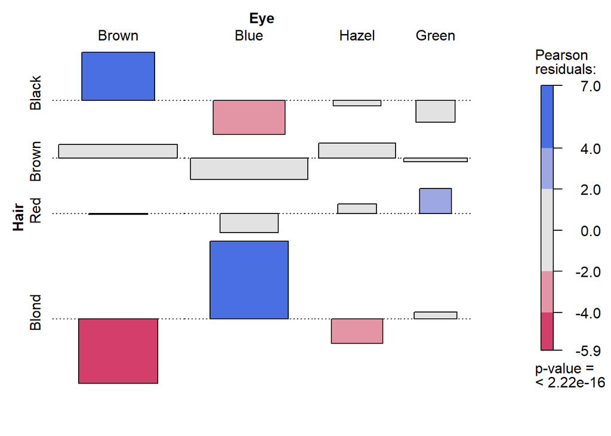

```r
assoc(~ Hair + Eye, data = HairEyeColor, shade = TRUE)
```

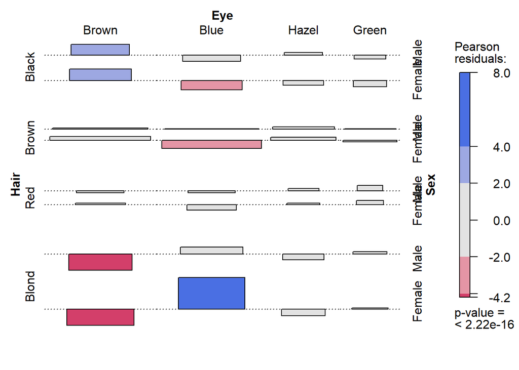

```r
assoc(HairEyeColor, shade = TRUE)
```

위의 그림은 기존의 머리색깔과 눈색깔의 연관성에 더해 성별을 계층변수로 추가한 `association plot`이다.  
성별에 관계없이, **Hair = Black, Eye = Brown**일 때, 공통적으로 양의 잔차를 가지고 **Hair = Blond, Eye = Brown**일 때, 공통적으로 음의 잔차를 가지는 것을 확인할 수 있다.

## 4.7 Observer agreement

행 변수와 열 변수가 서로 다른 관찰자의 동일한 주체 또는 개체 등급을 나타내는 경우 관심은 단순한 연관성 보다 **observer agreement(관찰자의 동의)**가 중요하다.  
이 경우, 합의의 측정 및 시험은 주관적인 분류 또는 평가 절차의 신뢰성을 평가하는 방법을 제공한다.

예를 들어, 두 명 이상의 심리학자는 (a)정상, (b)경미한 손상, (c)심각하게 손상된 범주의 규모로 환자를 분류할 수 있다. 이러한 예시에서 알 수 있듯이 등급 범주는 종종 정렬되지만, 항상 정렬되는 것은 아니다.  
대부분의 경우, 동일한 범주가 두 평가자에 의해 사용 되므르 분할표는 정사각형이며, 대각 셀의 항목은 평가자가 동일하는 경우이다.

*Example 4.16: Sex is fun*

```r
data("SexualFun", package = "vcd")
SexualFun
```

```
##               Wife
## Husband        Never Fun Fairly Often Very Often Always fun
##   Never Fun            7            7          2          3
##   Fairly Often         2            8          3          7
##   Very Often           1            5          4          9
##   Always fun           2            8          9         14
```

`SexualFun`데이터는 설문지 항목에 대한 부부의 반응을 요약한 것으로 서로의 성관계에 대한 만족도를 제공하는 데이터이며, `vcd`패키지 안에 포함돼있다.

- Husband: 남편의 만족도 (Factor variable - Never, Fairly often, very often, Always)
- Wife: 부인의 만족도 (Factor variable - Never, Fairly often, very often, Always)

각 행에서 대각선 항목이 항상 큰 것은 아니지만, 파트너 중 하나가 **거의 항상**이라고 응답할 때 더 자주 동의하는 경향이 있는 것처럼 보인다.

*Example 4.17: Diagnosis of MS patients*

`MSPatients`데이터는 다발성 경화증 환자 진단에 대한 위니펙과 뉴올리언스의 두 명의 신경학자가 평가한 데이터로 `vcd`패키지 안에 포함돼있다.

- New Orleans Neurologist: 뉴올리언스 신경학자가 평가한 환자의 상태 (Factor variable Certain, Probable, Possible, Doubtful)
- Winnipeg Neurologist: 위니펙 신경학자가 평가한 환자의 상태 (Factor variable - Certain, Probable, Possible, Doubtful)
- patients: 환자의 소속 주 (Factor variable - Winnipeg, New Orleans)

```r
MSPatients[, , "Winnipeg"]
```

```
##                        Winnipeg Neurologist
## New Orleans Neurologist Certain Probable Possible Doubtful
##                Certain       38        5        0        1
##                Probable      33       11        3        0
##                Possible      10       14        5        6
##                Doubtful       3        7        3       10
```

```r
MSPatients[, , "New Orleans"]
```

```
##                        Winnipeg Neurologist
## New Orleans Neurologist Certain Probable Possible Doubtful
##                Certain        5        3        0        0
##                Probable       3       11        4        0
##                Possible       2       13        3        4
##                Doubtful       1        2        4       14
```

```r
apply(MSPatients, 3, sum)
```

```
##    Winnipeg New Orleans
##         149          69
```

`MSPatients`데이터는 4x4x2표로 구성돼 있으며, 환자가 소속된 주를 계층으로 사용했다.  
winnipeg의 환자의 수는 149명, New Orleans의 환자의 수는 69명인 것을 확인할 수 있다.

### 4.7.1 Measuring agreement

동의의 강도를 평가할 때 우리는 일반적으로 연관성의 강도를 측정할 때 보다 더 엄격한 기준을 가지고 있다. 이는 관찰자 등급은 강한 합의 없이 강하게 연관될 수 있기 때문이다. 예를 들어, 한 평가자가 더 엄격한 기준을 사용할 수 있으므로 다른 평가자보다 등급이 낮을 수 있다.  
따라서, 여러명의 평가자를 고려할 때에는 특정 평가자의 평가를 통해 기준이 한 쪽으로 쏠리지 않도록 공평한 평가가 이루어지게 하는 것이 중요하다.

#### 4.7.1.4 Computing Kappa

코헨의 **Kappa**는 두 관찰자의 등급이 독립적일 경우 관측된 합의와 우연히 예상되는 합의를 비교하는 일반적으로 사용되는 합의 척도이다.  
$p_{ij}$가 무작위로 선택된 피실험자가 i에서 첫 번째 등급으로 평가될 확률일 경우 관찰자와 다른 범주 j에서 관찰된 합은 대각선 엔트리의 합이다. $P_0 = \sum_i(p_{ii})$ 등급이 독립적이라면, 합의 확률은 $P_C = \sum_i(p_i+p+i)$이다.  
코헨의 k는 실제 합치도와 우연 합치도의 차이 $P_0 - P_C$를 이 차이가 얻을 수 있는 최대값에 대한 비율이다.

$$k = {{P_0 - P_c} \over {1 - P_c}}$$

R에서 `Kappa`는 `vcd`패키지를 통해 사용할 수 있다.  
- `Kappa(table)`

- table: Kappa 함수를 적용할 교차표

또한, Kappa의 **가설검정**은 다음과 같이 진행할 수 있다.

- H0: 평가자의 등급은 우연에 기인한다.
- H1: 평가자의 등급은 우연에 기인하지 않는다.

```r
Kappa(SexualFun)
```

```
##             value     ASE     z Pr(>|z|)
## Unweighted 0.1293 0.06860 1.885 0.059387
## Weighted   0.2374 0.07832 3.031 0.002437
```

`SexualFun`변수에 `Kappa`함수를 사용하여 코헨의 **Kappa**를 구해보았다.  
가중치를 주지않는 경우에는 **Kappa = 0.1293**, 가중치를 주는 경우에는 **Kappa = 0.2374**로 가중치를 주었을 때, 더 큰 유사성을 보이는 것을 확인하였다.

또한, 가중치를 주지않는 경우의 유의확률은 유의수준 0.05보다 크므로 귀무가설을 기각하지 못한다. 따라서, 평가자의 등급평가는 우연이라고 할 수 있다.  
가중치를 주는 경우의 유의확률은 유의수준 0.05보다 작으므로 귀무가설을 기각한다. 따라서, 평가자의 등급은 우연에 기인하지 않는다고 할 수 있다.

```r
confint(Kappa(SexualFun))
```

```
##
## Kappa                 lwr       upr
##   Unweighted -0.005120399 0.2637809
##   Weighted    0.083883432 0.3908778
```

```r
summary(Kappa(SexualFun))
```

```
##             value     ASE     z Pr(>|z|)
## Unweighted 0.1293 0.06860 1.885 0.059387
## Weighted   0.2374 0.07832 3.031 0.002437
##
## Weights:
##           [,1]      [,2]      [,3]      [,4]
## [1,] 1.0000000 0.6666667 0.3333333 0.0000000
## [2,] 0.6666667 1.0000000 0.6666667 0.3333333
## [3,] 0.3333333 0.6666667 1.0000000 0.6666667
## [4,] 0.0000000 0.3333333 0.6666667 1.0000000
```

`confint`함수를 통해 kappa의 신뢰구간을 얻을 수 있다.  
가중치를 주지 않을 경우의 **Kappa** 95% 신뢰구간은 (-0.005,0.263) 이며, 가중치를 주는 경우의 95% 신뢰구간은 (0.084, 0.391)이다.

`summary`함수를 통해 kappa의 통계량 및 가설검정 뿐만아니라 가중치 정보 또한 확인할 수 있다.

### 4.7.2 Observer agreement chart

Bangdiwala가 제안한 **agreement chart**는 분할표에서 합의 강도와 간단한 그래픽 표현과 직관적인 해석을 통해 합의 강도의 대체 척도를 제공한다.  
더욱 중요한 것은, 합의가 완벽하지 않을 때 합의 불일치의 패턴을 보여준다.

#### 4.7.2.1 Construction of the baisc plot

k x k 분할표가 주어졌을 때, **agreement chart**는 n x n 정사각형으로 생성되며, 여기서 $n = n_{++}$는 총 표본 크기이다.  
각각의 크기가 $n_{ii}$x$n_{ii}$ 검은색 사각형은 관찰된 합의를 보여준다.  
완전한 합의일 경우, 주변 총합에 의해 결정된 k개의 직사각형은 모든 정사각형이며, 음영 정사각형으로 완전히 채워지면서 B=1이다.

R에서 `agreement chart`는 `vcd`패키지의 `agreementplot`을 사용하여 시각화할 수 있다.  
- `agreementplot(table, weights)`

- table: agreement chart를 그릴 교차표
- weights: 가중치 설정 (default는 자동으로 가중치를 만들어주고 weights = 1로 설정하면 가중치가 없는 것이다.)

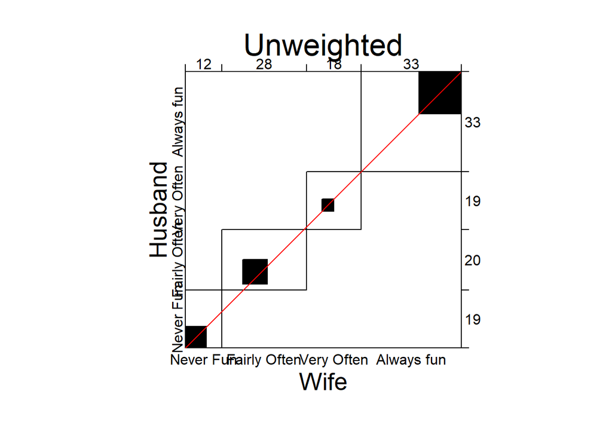

```r
agreementplot(SexualFun, main = "Unweighted", weights = 1)
```

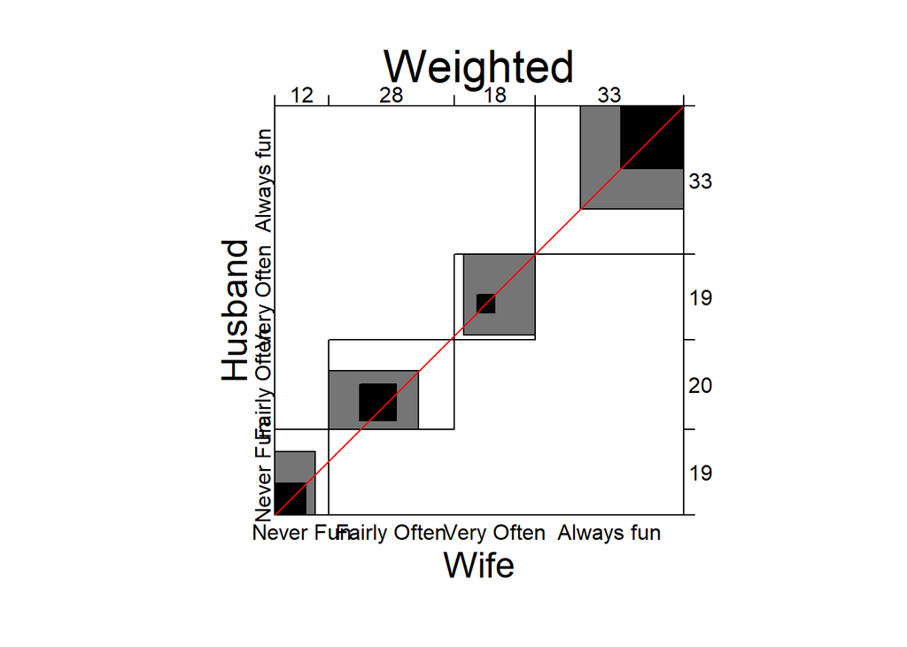

```r
agreementplot(SexualFun, main = "Weighted")
```

위의 그림은 가중치를 고려하지 않는 경우의 `agreementplot`이며, 아래 그림의 경우 가중치를 고려하는 경우의 `agreementplot`이다.  
검은색 사각형의 경우, 가중치를 고려하지 않는 경우의 일치도를 보여주며 회색 사각형의 경우 가중치를 고려하는 경우의 일치도를 보여준다.

가중치를 고려한 경우의 면적이 가중치를 고려하지 않은 경우보다 크며, 각 셀의 빈도 사각형을 고려했을 때에도 더 일치하는 것을 보여준다.  
따라서, 가중치를 고려한 경우의 평가자간 등급의 합의가 조금 더 일치하는 것을 확인할 수 있다.

#### 4.7.2.2 Partial agreement

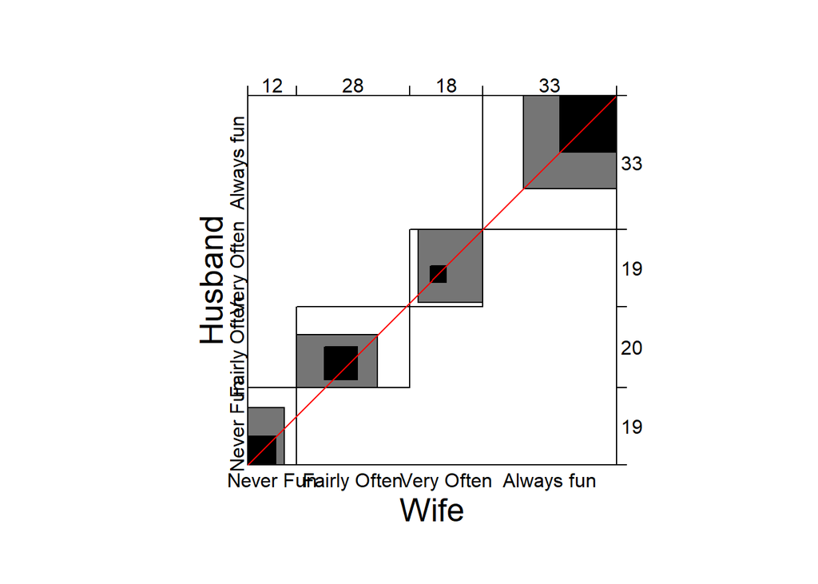

```r
B <- agreementplot(SexualFun)
```

```r
unlist(B)[1:2]
```

```
##          Bangdiwala Bangdiwala_Weighted
##           0.1464624           0.4981723
```

일치도 추정값인 `B`또한 가중치를 적용하지 않았을 때에는 0.146이지만, 가중치를 적용했을 때에는 0.498로 훨씬 더 일치도가 높은 것을 확인할 수 있다.

```r
data("Mammograms", package = "vcdExtra")
```

`Mammograms`는 두 명의 독자가 평가한 110개의 유방조영술에 대한 데이터로 테이블의 형태이며, `vcdExtra`패키지 안에 포함돼있다.

- Reader: 평가자인 독자 (Factor variable - Reader1, Reader2)
- Grade: 평가점수 (Factor variable - Absent,Minimal,Moderate,Severe)

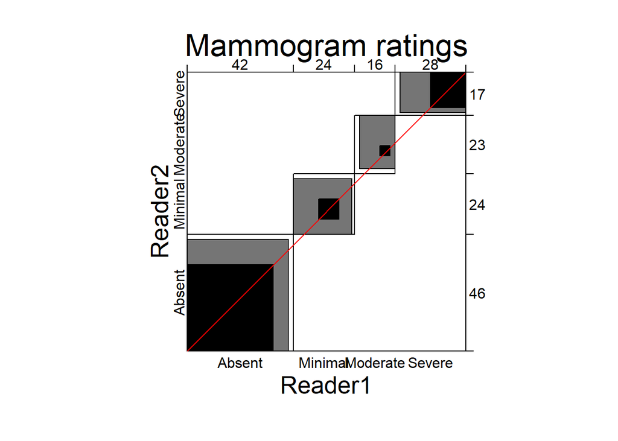

```r
B <- agreementplot(Mammograms, main = "Mammogram ratings")
```

`Mammograms` 데이터에 대한 `agreement plot`을 그려보았다. 검은색 사각형과 회색 사각형의 면적을 볼때, 앞서 살펴본 데이터보다 평가자간의 등급 일치도가 높은 것을 알 수 있다.  
또한, 두 평가자는 **Absent, Severe**와 같은 극단적인 범주에 더 자주 동의하는 것처럼 보인다.

```r
unlist(B) [1:2]
```

```
##          Bangdiwala Bangdiwala_Weighted
##           0.4272076           0.8366481
```

### 4.7.3 Observer bias in agreement

순서 척도를 사용하면 인접한 범주 사이의 경계에 대해 더 엄격한 임계값을 사용하기 때문에 한 관찰자가 다른 관찰자보다 더 높거나 낮은 범주로 개체를 일관되게 할당하는 위험이 발생할 수 있다.  
**관찰자 합도표는** 어두운 사각형과 대각선의 관계를 통해 이를 직접 보여준다. 주변 총량이 동일하면 사각형은 대각선을 따라 나간다.

*Example 4.19: Diagnosis of MS patients*

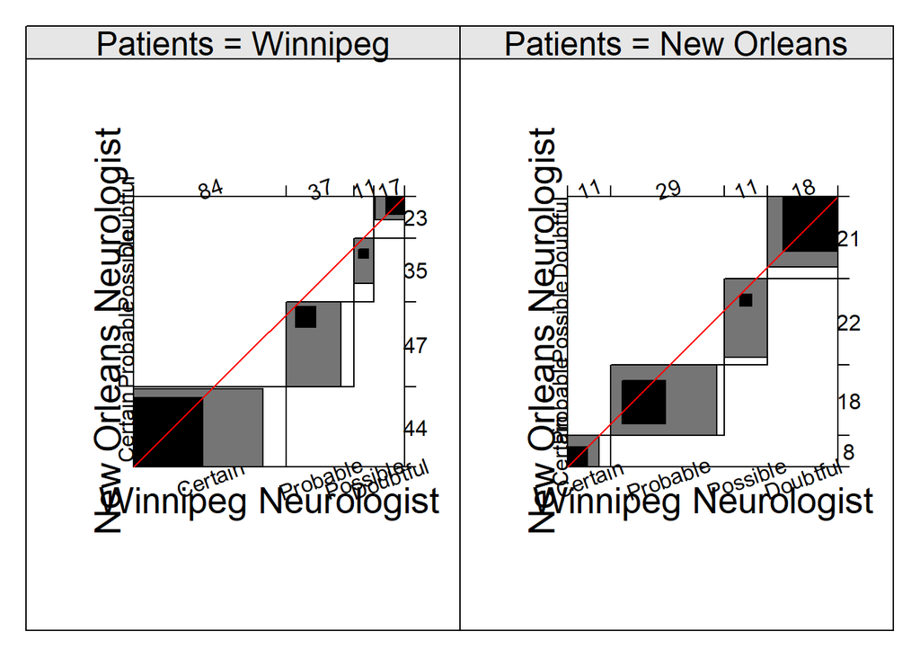

```r
cotabplot(MSPatients, cond = "Patients",
          panel = cotab_agreementplot,
          text_gp = gpar(fontsize = 18), xlab_rot = 20)
```

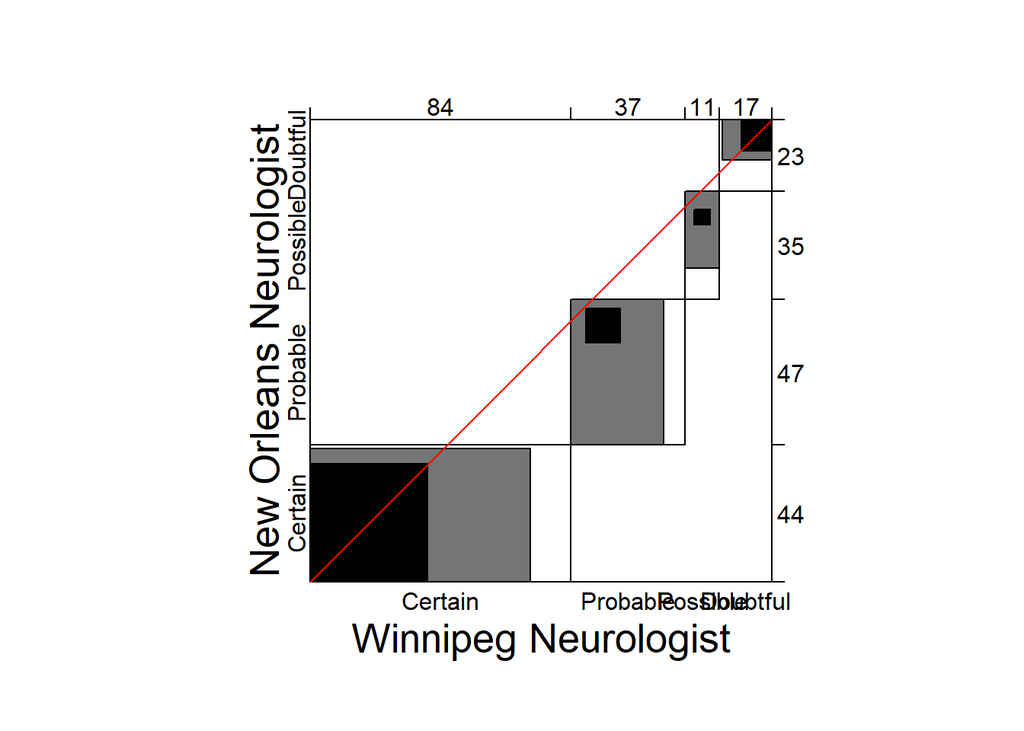

```r
agr1 <- agreementplot(MSPatients[, , "Winnipeg"])
```

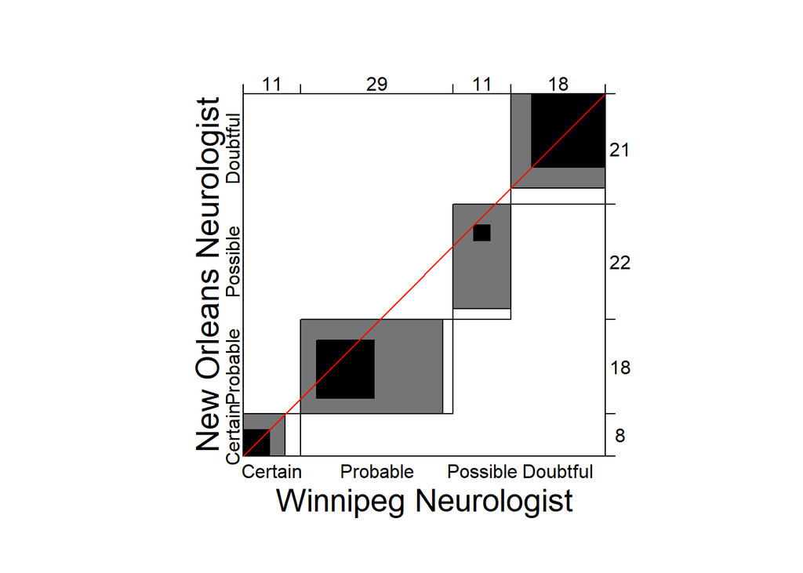

```r
agr2 <- agreementplot(MSPatients[, , "New Orleans"])
```

```r
rbind(Winning = unlist(agr1),
      NewOrleans = unlist(agr2))[, 1:2]
```

```
##            Bangdiwala Bangdiwala_Weighted
## Winning     0.2720979           0.7380812
## NewOrleans  0.2853659           0.8223126
```

두 환자 그룹의 경우, 두 중간 범주의 직사각형은 대각선 아래에 있음을 알 수 있다. 이것은 **New Orleans 신경학자, Winnipeg 신경학자**가 환자들을 더 심각한 진단 범주로 분류하는 경향이 있다는 것을 보여준다.  
대각선에서의 이탈은 **Winnipeg 환자들에게 더 크게** 나타나는 것을 볼 수 있으며, **New Orleans 환자에게는 Winnipeg 환자에 비해 더 심각한 범주를 적게 사용하여 대각선 이탈이 더 낮은 것**을 확인할 수 있다.

**Winnipeg, New Orleans**환자 모두 가중치를 적욯하지 않았을 때 보다, 가중치를 적용한 경우의 일치도가 훨씬 높게 나타나는 것을 알 수 있다.